# Neural Network Development with Micrograd Package

## Neural Network Development with Micrograd Package Southern Methodist University By Barry Daemi Updated: February 21, 2023 $$\newcommand{\C}{\mathbb{C}} \newcommand{\R}{\mathbb{R}} \newcommand{\Z}{\mathbb{Z}} \newcommand{\Q}{\mathbb{Q}} \newcommand{\P}{\mathbb{P}} \newcommand{\F}{\mathbb{F}} \newcommand{\N}{\mathbb{N}} \newcommand{\E}{\mathbb{E}}$$

Difficulty can arise in the development of a neural network when implementing backward propagation; in the past the most common issue that arose was that the optimization problem and the methodological approach to solve said optimization problem had to be hardcoded into the neural network code architecture. There exist no alternative to hardcoded implementations, and thus with this need to hardcoding one implementation - limited the depth that a neural networks could take, and the generality that a neural network algorithm could manifest so to be able to solve large data-driven problems, such as in Natural Language Processors (**NLP**) and advance image recognition or image manipulation software. To computate the partial derivatives needed to update each of the weight matrices and bais vectors, one had to implement an elaborate coding architecture that was hardcoded into the neural network code architecture, of which computated the desired partial derivatives that optimized the loss function optimization problem, but also updated the weight matrices and bais vectors.  
We hope that the difficulty of this approach has become apparent to the reader; the difficulty is that one needs not only to know the exact formulation of the partial derivatives in their analytic forms, but also know how to code said anayltic forms into the neural network's code architecture and have this implementation handle vectorized operations for efficient execution; e.g. as CPU can handle data in vector form more efficiently, implementing vectorized operations in the form of linear algebra matrix operations, significantly improves the computational efficiency of an algorithm. Though with the advent of forward automatic differentiation (**FAD**) [0] and reverved automatic differentiation (**RAD**) [[1](https://book.sciml.ai/notes/10-Basic_Parameter_Estimation-Reverse-Mode_AD-and_Inverse_Problems/)] the need for explicit hard-coding of the scheme to computate partial derivative become an antiquated practice; as if one can implement an **RAD** scheme, one can automate the computation process for attaining partial derivatives for the background propagation phase of training [[1](https://book.sciml.ai/notes/10-Basic_Parameter_Estimation-Reverse-Mode_AD-and_Inverse_Problems/),[2](https://arxiv.org/pdf/1804.00746.pdf)]. And unlike the traditional schemes of Numerical differentiation and Manual differentiation which approximates a complete or partial derivative; **FAD** and **RAD** schema both computate the exact complete or partial derivative avoiding the complication caused by trunction Error and roundoff Error, which are byproducts to the representation and computational limitations of Double-precision floating-point format (**float64**) and Extended-Double-precision floating-point format (**float80**) in the accepted standard IEEE-754 for Standard for Floating-Point Arithmetic [[3](https://www.jmlr.org/papers/volume18/17-468/17-468.pdf),[4](https://softwareengineering.stackexchange.com/questions/120886/cpu-architecture-and-floating-point-math),[5](https://heyrick.eu/assembler/fpops.html),[6](https://en.wikipedia.org/wiki/IEEE_754)]. The limitations of Standard for Floating-Point Arithmetic in the most commonly implemented **float64** framework, results in serious limitations and contraints to the applicability to implement Numerical differentiation in algorithmic applications (e.g. use of Numerical differentiation) or algorithm development (e.g. implementation of Numerical differentiation in an algorithms' code architecture); but FAD and RAD hold no such Floating-Point Arithmetic limitations and it implementation lead to fluent automation, and it is for this reason why automatic differentiation schema have surplanted hard-coded derivative approximation schema in the world of machine learning and Artificial Intelligence.  
An open-source Python package named, PyTorch, developed by Meta AI research, seemingly popularized and proliferated the use of reversed automatic differentiation (**RAD**) in machine learning and AI development; Pytorch greatly simplified the process to implement backward propagation, which held back deep learning models of the past; instead of coding very complicated algebraic formed equations - attained through manual differentiation and executed with IEEE-754; one was able to rely on PyTorch Autograd Engine [[7](https://openreview.net/pdf?id=BJJsrmfCZ),[8](https://pytorch.org/blog/overview-of-pytorch-autograd-engine/),[9](https://pytorch.org/tutorials/beginner/basics/autogradqs_tutorial.html)] to evaluate exact partial derivatives to each backward propagation process and pass it on to the respective optimization step. A more simplified **RAD** schema for Python was developed by an AI researcher, Andrej Karpathy, **Micrograd**; a self-contained open-source machine learning package. Being a self-contained package like PyTorch, **Micrograd** contains all the necessary functionality needed to implement any machine learning algorithm and deep learning model. The purpose of this project is to demonstrate the functionality of **Micrograd**, and it utility as a self-contained open-source package to develop machine learning and deep learning models for the purposes research and low-intensity application. For the purposes of this project, we did not simply import Micrograd and implement its packaged functions, instead we used a slightly modified version of the source-code to apply it to a series of applications; Micrograd's GitHub's page can be found here [[10](https://github.com/karpathy/micrograd)].  
In the following code block contains the list of Python packages utilized in this project: `random`, `math`, `numpy`, `scipy.stats`, `scipy.special`, `pandas`, `matplotlib.pyplot`, `copy`, `sklearn`, `seaborn` and `IPython.core.display`. On a side note, we imported `IPython.core.display` to implement some CSS code to stylize our documentation.

```python
import random
import math
import numpy as np
from scipy.stats import norm
import scipy.special as sp
import pandas as pd
import matplotlib.pyplot as plt
import copy as copy
from sklearn import metrics
import seaborn
from IPython.core.display import HTML
HTML("""
<style>
ul.no-bullets {
  list-style-type: none;
  margin: 0;
  padding: 0;
}

figcaption {
  background-color: black;
  color: white;
  font-style: Time New Roman;
  padding: 2px;
  text-align: center;
  max-width: 500px;
  margin: auto auto;
}
</style>
""")
```

Proceeding, the following is the modified source code to `Micrograd.Value` [[11](https://github.com/karpathy/micrograd/blob/master/micrograd/engine.py)], for the purposes of this project we added several additional elementary functions [[12](https://en.wikipedia.org/wiki/Elementary_function)], and some additional activation functions [[13](https://en.wikipedia.org/wiki/Activation_function)]. In the following code blocks, we will provide the reader with several mathematical examples, these examples will demonstrate the utility and functionality of `Micrograd.Value`; in said examples we will utilize `Micrograd.Value` to perform univariate calculus with IEEE-754 (floating-point arithmetic).

```python
class Value:
    """ stores a single scalar value and its gradient """ # Credit to Andrej Karpathy
                                                          # for the source code to Micrograd.Value

    def __init__(self, data,_children=(),_op=''):
        self.data=data;
        self.grad=0;
        # internal variables used for autograd graph construction
        self._backward=lambda: None;
        self._prev=set(_children);
        # the op that produced this node, for graphviz / debugging / etc
        self._op=_op;
    def __add__(self, other):
        other=other if isinstance(other, Value) else Value(other);
        out=Value(self.data+other.data,(self,other),'+');
        def _backward():
            self.grad+=out.grad
            other.grad+=out.grad
        out._backward=_backward
        return out;
    def __mul__(self,other):
        other=other if isinstance(other,Value) else Value(other);
        out=Value(self.data*other.data,(self,other),'*');
        def _backward():
            self.grad+=other.data*out.grad;
            other.grad+=self.data*out.grad;
        out._backward=_backward;
        return out;
    def __pow__(self,other):
        assert isinstance(other,(int,float)),"only supporting int/float powers for now";
        out=Value(self.data**other,(self,),f'**{other}');
        def _backward():
            self.grad+=(other*self.data**(other-1))*out.grad;
        out._backward=_backward;
        return out;
    def log(self):
        x=self.data;
        out=Value(np.log(x),(self,),'Log');
        def _backward():
            self.grad+=(1*self.data**-1)*out.grad;
        out._backward=_backward;
        return out;
    def cos(self):
        x=self.data;
        out=Value(np.cos(x),(self,),'Cos');
        def _backward():
            self.grad+=(-1*np.sin(self.data))*out.grad;
        out._backward=_backward;
        return out;
    def sin(self):
        x=self.data;
        out=Value(np.sin(x),(self,),'Sin');
        def _backward():
            self.grad+=(-1*np.cos(self.data))*out.grad;
        out._backward=_backward;
        return out;
    def tan(self):
        x=self.data;
        out=Value(np.tan(x),(self,),'Tan');
        def _backward():
            self.grad+=((1/np.cos(x))**2)*out.grad;
        out._backward=_backward;
        return out;
    def sqrt(self):
        x=self.data;
        out=Value(np.sqrt(self.data),(self,),'sqrt');
        def _backward():
            self.grad+=(1/(2*np.sqrt(self.data)))*out.grad;
        out._backward=_backward;
        return out;
    def relu(self):
        out = Value(0 if self.data < 0 else self.data,(self,),'ReLU');
        def _backward():
            self.grad+=(out.data > 0)*out.grad;
        out._backward=_backward;
        return out;
    def tanh(self):
        x=self.data;
        #t=(math.exp(2*x)-1)/(math.exp(2*x)+1);
        t=np.tanh(x);
        out=Value(t,(self,),'tanh');
        def _backward():
            self.grad+=(1-t**2)*out.grad;
        out._backward=_backward;
        return out;
    def sigmoid(self):
        x=self.data;
        t=(1/(1+np.exp(x)));
        out=Value(t,(self,),'Sigmoid');
        def _backward():
            self.grad+=(np.exp(x)/((np.exp(x)+1)**2))*out.grad;
        out._backward=_backward;
        return out;
    def softplus(self):
        x=self.data;
        out=Value(np.log(1+np.exp(self.data)),(self,),'softplus');
        def _backward():
            self.grad+=(1/(1+np.exp(-1*self.data)))*out.grad;
        out._backward=_backward;
        return out;
    def backward(self):
        # topological order all of the children in the graph
        topo=[];
        visited=set();
        def build_topo(v):
            if v not in visited:
                visited.add(v);
                for child in v._prev:
                    build_topo(child);
                topo.append(v);
        build_topo(self);
        # go one variable at a time and apply the chain rule to get its gradient
        self.grad=1;
        for v in reversed(topo):
            v._backward();
        pass
    def __neg__(self): # -self
        return self*-1;
    def __radd__(self,other): # other + self
        return self+other;
    def __sub__(self,other): # self - other
        return self+(-other);
    def __rsub__(self,other): # other - self
        return other+(-self);
    def __rmul__(self,other): # other * self
        return self*other;
    def __truediv__(self,other): # self / other
        return self*other**-1;
    def __rtruediv__(self, other): # other / self
        return other*self**-1;
    def __repr__(self):
        return f"Value(data={self.data}, grad={self.grad})";
```

To encapsulate the desired numeric for mathematics operations, just pass the individual numeric values through the `Value()`; the function will encapulate the numeric value in a Python `set()`. To access the data, just use `.data`, and the data will be return to console, or stored into an object.

```python
a=Value(5.0); b=Value(7.0); d=Value(1/2);
c=d*(a+b);
print("c: "+str(c));
print("C's Data: "+str(c.data));
Object=c.data
print("C's Data stored in Object: "+ "Object = " +str(Object));
```

```
c: Value(data=6.0, grad=0)
C's Data: 6.0
C's Data stored in Object: Object = 6.0
```

For more complex mathematics, we can pass vector arrays into the `Value()` to encapulate a larger set of numbers, so that we can perform calculate more so native to advance mathematics. As important as functional mathematical operations are, it was also critical that `Value()` be able to evaluate encapsulated values with elementary functions, such as, $\cos(x)$, $\sin(x)$, $\tan(x)$, $\log(x)$, et ceteria. To demonstration this feature, we choice to map, $y=\sin(x)$ over the closed interval, $-\pi \leq x \leq \pi$.

```
a: Value(data=[-3.14159265 -2.81089869 -2.48020473 -2.14951076 -1.8188168  -1.48812284
 -1.15742887 -0.82673491 -0.49604095 -0.16534698  0.16534698  0.49604095
  0.82673491  1.15742887  1.48812284  1.8188168   2.14951076  2.48020473
  2.81089869  3.14159265], grad=0)
```

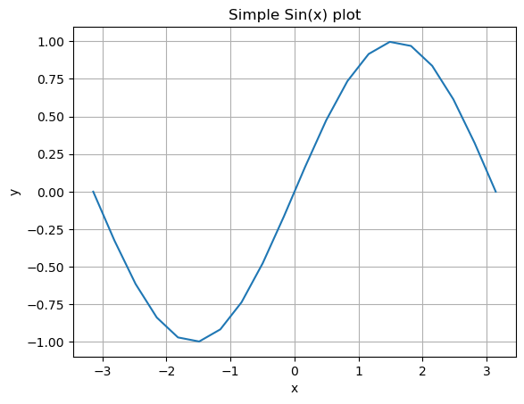

```python
a=Value(np.linspace(-1.0*math.pi,1.0*math.pi,20)); a.label='a'; # -pi to +pi: 20 partitions
print("a: "+str(a));
b=a.sin();
plt.plot(a.data,b.data); # plots a.data against b.data
plt.title("Simple Sin(x) plot");
plt.xlabel("x");
plt.ylabel("y");
plt.grid()
```

Lets get a little pathological, and select a pathological function to contruct next; it would be a perfect example to demonstrate reverved automatic differentiation (**RAF**), and compared its results to a manual differentiation - where we attained the analytic form of $f'(x)$. We selected the following pathological equation from a Real Analysis textbook, *A First Course in Real Analysis*, second edition, by M.H Protter and C.B. Morrey [[14](https://link.springer.com/book/10.1007/978-1-4615-9990-6)], its interesting behavior as a function, and the complexity of its first derivative made this pathological function the perfect demonstration function. But first let's derivative the analytic form of $f(x)$'s first derivative, $f'(x)$.

$$f(x)=\sqrt{\frac{3(x+2)(x^{2}+4)}{2(x^{2}+2x+4)}} \; \;\text{for interval} \; -2 \leq x \leq 5.$$

Manual differentiation by hand:

$$\frac{df}{dx}=\frac{d}{dx} \sqrt{\frac{3(x+2)(x^{2}+4)}{2(x^{2}+2x+4)}}=\sqrt{\frac{3}{2}} \cdot \frac{d}{dx} \bigg[ \sqrt{x^{2}+4} \cdot \sqrt{\frac{x+2}{x^{2}+2x+4}} \: \bigg]$$

$$=\sqrt{\frac{3}{2}} \cdot \bigg( \frac{d}{dx}\big[ \sqrt{x^{2}+4} \: \big] \cdot \sqrt{\frac{x+2}{x^{2}+2x+4}} + \sqrt{x^{2}+4} \cdot \frac{d}{dx} \bigg[ \sqrt{\frac{x+2}{x^{2}+2x+4}} \: \bigg] \bigg)$$

$$=\sqrt{\frac{3}{2}} \cdot \bigg( \frac{1}{2} \cdot \big( x^{2}+4 \big)^{-\frac{1}{2}} \cdot \frac{d}{dx} \big[ x^{2}+4 \big] \cdot \sqrt{\frac{x+2}{x^{2}+2x+4}} + \sqrt{x^{2}+4} \cdot \frac{1}{2} \cdot \bigg( \frac{x+2}{x^{2}+2x+4} \bigg)^{-\frac{1}{2}} \cdot \frac{d}{dx} \bigg[ \frac{x+2}{x^{2}+2x+4} \: \bigg] \bigg)$$

$$=\sqrt{\frac{3}{2}} \cdot \Bigg( \frac{\big( \frac{d}{dx}\big[x^{2}\big]+\frac{d}{dx} \big[4\big]\big)\sqrt{\frac{x+2}{x^{2}+2x+4}}}{2\sqrt{x^{2}+4}} + \frac{\sqrt{x^{2}+4} \cdot \frac{\frac{d}{dx}\big[x+2 \big] \cdot \big( x^{2}+2x+4 \big)-(x+2) \cdot \frac{d}{dx}\big[ x^{2}+2x+4 \big]}{\big( x^{2}+2x+4 \big)^{2}} }{2\sqrt{\frac{x+2}{x^{2}+2x+4}}} \Bigg)$$

$$=\sqrt{\frac{3}{2}} \cdot \Bigg( \frac{ 2x\sqrt{\frac{x+2}{x^{2}+2x+4}}}{2\sqrt{x^{2}+4}} + \frac{\sqrt{x^{2}+4} \cdot \bigg( \frac{d}{dx}\big[x+2 \big] \cdot \big( x^{2}+2x+4 \big)-\big(x+2\big) \cdot \frac{d}{dx}\big[ x^{2}+2x+4 \big] \bigg) }{2\big( x^{2}+2x+4 \big)^{2}\sqrt{\frac{x+2}{x^{2}+2x+4}}} \Bigg)$$

$$=\sqrt{\frac{3}{2}} \cdot \Bigg( \frac{ 2x\sqrt{\frac{x+2}{x^{2}+2x+4}}}{2\sqrt{x^{2}+4}} + \frac{\sqrt{x^{2}+4} \cdot \bigg( \big( \frac{d}{dx}\big[ x \big] + \frac{d}{dx} \big[ 2 \big] \big) \cdot \big( x^{2}+2x+4 \big)-\big(x+2\big) \cdot \big( \frac{d}{dx}\big[ x^{2} \big] + \frac{d}{dx} \big[2x\big] + \frac{d}{dx} \big[ 4 \big] \big) \bigg)}{2\big( x^{2}+2x+4 \big)^{2}\sqrt{\frac{x+2}{x^{2}+2x+4}}} \Bigg)$$

$$=\sqrt{\frac{3}{2}} \cdot \Bigg( \frac{ x\sqrt{\frac{x+2}{x^{2}+2x+4}}}{\sqrt{x^{2}+4}} + \frac{\sqrt{x^{2}+4} \cdot \bigg( \big( 1+0\big) \cdot \big( x^{2}+2x+4 \big)-\big(x+2\big) \cdot \big( 2x + 2 + 0 \big) \bigg)}{2\big( x^{2}+2x+4 \big)^{2}\sqrt{\frac{x+2}{x^{2}+2x+4}}} \Bigg)$$

$$=\sqrt{\frac{3}{2}} \cdot \Bigg( \frac{ x\sqrt{\frac{x+2}{x^{2}+2x+4}}}{\sqrt{x^{2}+4}} + \frac{\sqrt{x^{2}+4} \cdot \bigg( \big( x^{2}+2x+4 \big)-\big(x+2\big) \cdot \big( 2x + 2 \big) \bigg)}{2\big( x^{2}+2x+4 \big)^{2}\sqrt{\frac{x+2}{x^{2}+2x+4}}} \Bigg)$$

$$=\sqrt{\frac{3}{2}} \cdot \Bigg( \frac{ x\sqrt{\frac{x+2}{x^{2}+2x+4}}}{\sqrt{x^{2}+4}} + \frac{\sqrt{x^{2}+4} \cdot \bigg( x^{2}-\big( x+2 \big)\big( 2x+2 \big)+2x+4 \bigg)}{2\big( x^{2}+2x+4 \big)^{2}\sqrt{\frac{x+2}{x^{2}+2x+4}}} \Bigg)$$

$$=\frac{\sqrt{3}x^{2} \cdot \big( x^{2}+4x+12\big)}{2^{3/2}\sqrt{x^{2}+2x+4}\big( x^{2}+2x+4 \big)^{2}\sqrt{\frac{x+2}{x^{2}+2x+4}}}. \: \square$$

```python
# Reverse Automatic Differentiation
x=Value(np.linspace(-1.9999,-1,10));
y=((3*(x+2)*(x**2+4))/(2*(x**2+(2*x)+4))).sqrt();
y.backward();
# Exact manual derivative of the pathological function: f(x)
temp1=Value(3.0).sqrt(); temp2=Value(2)**(3/2); temp3=(x**2+4).sqrt(); temp4=((x+2)/(x**2+2*x+4)).sqrt();
Exact_Der=(temp1*(x**2)*(x**2+4*x+12))/(temp2*temp3*((x**2+2*x+4)**2)*temp4);
# Finite Difference Method - Numerical Differentiation
h=1.4901161193847656e-8;
Num_diff=((((3*((x+h)+2)*((x+h)**2+4))/(2*((x+h)**2+(2*(x+h))+4))).sqrt())-(((3*(x+2)*(x**2+4))/(2*(x**2+(2*x)+4))).sqrt()))/h;
print(" ")
print("L-2 Norm Error for RAD and Manual Differentiation: " + str(np.linalg.norm(x.grad-Exact_Der.data)))
print("L-2 Norm Error for RAD and Numerical Differentiation: " + str(np.linalg.norm(x.grad-Num_diff.data)))
print("L-2 Norm Error for Manual Differentiation and Numerical Differentiation: "
      + str(np.linalg.norm(Exact_Der.data-Num_diff.data)));
Data=pd.DataFrame({'Reversed Automatic Differentiation': x.grad, 'Manual Differentiation': Exact_Der.data,
              'Numerical Differentiation': Num_diff.data }).T
Data.columns=['f(x1)','f(x2)','f(x3)','f(x4)','f(x5)','f(x6)','f(x7)','f(x8)','f(x9)','f(x10)'];
Data
```

```
L-2 Norm Error for RAD and Manual Differentiation: 8.1773032027145e-16
L-2 Norm Error for RAD and Numerical Differentiation: 0.0032259557682325357
L-2 Norm Error for Manual Differentiation and Numerical Differentiation: 0.0032259557682325357
```

|  | f(x1) | f(x2) | f(x3) | f(x4) | f(x5) | f(x6) | f(x7) | f(x8) | f(x9) | f(x10) |
| --- | --- | --- | --- | --- | --- | --- | --- | --- | --- | --- |
| Reversed Automatic Differentiation | 86.602540 | 2.586217 | 1.804012 | 1.435753 | 1.194785 | 1.009605 | 0.85356 | 0.715096 | 0.589244 | 0.474342 |
| Manual Differentiation | 86.602540 | 2.586217 | 1.804012 | 1.435753 | 1.194785 | 1.009605 | 0.85356 | 0.715096 | 0.589244 | 0.474342 |
| Numerical Differentiation | 86.599314 | 2.586217 | 1.804011 | 1.435753 | 1.194785 | 1.009605 | 0.85356 | 0.715096 | 0.589244 | 0.474342 |

```
L-2 Norm Error for RAD and Manual Differentiation: 8.50681253451778e-14
L-2 Norm Error for RAD and Numerical Differentiation: 0.0037743527515592327
L-2 Norm Error for Manual Differentiation and Numerical Differentiation: 0.0037743527515596573
```

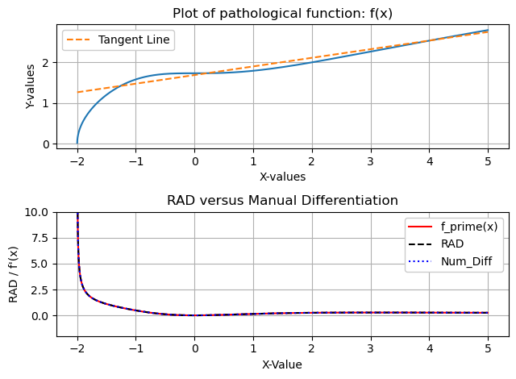

```python
# Reverse Automatic Differentiation
x=Value(np.linspace(-1.9999,5,100000));
y=((3*(x+2)*(x**2+4))/(2*(x**2+(2*x)+4))).sqrt();
y.backward();

# Exact manual derivative of the pathological function: f(x)
temp1=Value(3.0).sqrt(); temp2=Value(2)**(3/2); temp3=(x**2+4).sqrt(); temp4=((x+2)/(x**2+2*x+4)).sqrt();
Exact_Der=(temp1*(x**2)*(x**2+4*x+12))/(temp2*temp3*((x**2+2*x+4)**2)*temp4);

# Finite Difference Method - Numerical Differentiation
h=1.4901161193847656e-8;
Num_diff=((((3*((x+h)+2)*((x+h)**2+4))/(2*((x+h)**2+(2*(x+h))+4))).sqrt())-(((3*(x+2)*(x**2+4))/(2*(x**2+(2*x)+4))).sqrt()))/h;

# Example tangent line
x0=x.grad[50000];
dfdx=x.grad[50000];
Ex_tangent_line=(dfdx*(x.data-x0))+(np.sqrt(((3*(x0+2)*(x0**2+4))/(2*(x0**2+(2*x0)+4)))));

# Print the L-2 Norm Error
print("L-2 Norm Error for RAD and Manual Differentiation: " + str(np.linalg.norm(x.grad-Exact_Der.data)))
print("L-2 Norm Error for RAD and Numerical Differentiation: " + str(np.linalg.norm(x.grad-Num_diff.data)))
print("L-2 Norm Error for Manual Differentiation and Numerical Differentiation: "
      + str(np.linalg.norm(Exact_Der.data-Num_diff.data)));

plt.subplot(2,1,1);
plt.plot(x.data,y.data);
plt.plot(x.data,Ex_tangent_line,linestyle='dashed',label='Tangent Line');
plt.grid();
plt.title("Plot of pathological function: f(x)");
plt.xlabel("X-values");
plt.ylabel("Y-values");
plt.legend(framealpha=1,frameon=True);
plt.subplot(2,1,2);
plt.plot(x.data,Exact_Der.data,color='red',label='f_prime(x)');
plt.plot(x.data,x.grad,color='black',linestyle='dashed',label='RAD');
plt.plot(x.data,Num_diff.data,color='blue',linestyle='dotted',label='Num_Diff');
plt.grid();
plt.title("RAD versus Manual Differentiation");
plt.xlabel("X-Value");
plt.ylabel("RAD / f'(x)");
plt.ylim(-2,10);
plt.legend(framealpha=1,frameon=True);
plt.tight_layout();
plt.show();
```

Glancing at the graph above might give the impression that each differentiation schema are equivalently computationally stable and well-conditioned methods; though as displayed in L-2 norm error values, numerical differentiation is by far the worst method. Its issues lie entirely in the limitations with **Float64**, indeed the finite difference scheme is the definition of differentiation in calculus, but the underlynning concept of a infinitesimal value, such as $h$, is a impossible concept to implement in finite representation, without trunction or round-off; as a result the only feasible way to implement a finite difference scheme is to accept some degree of error in the final solution, and to properly measure an half way point to the current machine epsilon to choice a appropraite $h$ value. Converging to the point, this slight ill-conditionness of Numerical differentiation limits the application of such a numerical difference scheme to smaller neural networks, as the round-off error would be negligible at that size.  
Borrowing the Graphviz code from Andrej Karpathy YouTube video, *The spelled-out intro to neural networks and backpropagation: building microghrad* [[17](https://www.youtube.com/watch?v=VMj-3S1tku0&ab_channel=AndrejKarpathy)],

```
    # Url: https://graphviz.org/
    from graphviz import Digraph

    def trace(root):
        # Builds a set of all nodes and edges in a graph
        nodes,edges=set(),set()
        def build(v):
            if v not in nodes:
                nodes.add(v);
                for child in v._prev:
                    edges.add((child,v));
                    build(child);
        build(root);
        return nodes,edges;

    def draw_dot(root):
        dot=Digraph(format='svg',graph_attr={'rankdir': 'LR'}); # LR = left to right

        nodes,edges=trace(root)
        for n in nodes:
            uid=str(id(n));
            # for any values in the graph, create a rectangular ('record') node for it
            dot.node(name=uid,label="{data %.4f | grad %.4f}" % (n.data, n.grad),shape='record');
            if n._op:
                # if this value is a result of some operation, create an op node for it
                dot.node(name=uid+n._op,label=n._op);
                # and connect this node to it
                dot.edge(uid+n._op,uid);

        for n1,n2 in edges:
            # connect n1 to the op nodes of n2
            dot.edge(str(id(n1)),str(id(n2))+n2._op);

        return dot;
```

Figure 1 - Andrej Karpathy's Graphviz code from YouTube Video, *The spelled-out intro to neural networks and backpropagation: building micrograd* (Date: Aug. 16, 2022).

we were able to create two Digraphs that depicted the decomposition of differentials maps, one for **AD** and one for numerical differentiation. Firstly we choice $f(x)$ from the previous demonstrate to create the decomposition of differentials maps for both schema:

$$f(x)=\sqrt{\frac{3(x+2)(x^{2}+4)}{2(x^{2}+2x+4)}}.$$

Chose `X=Value(1.75)` for the x-value, and `h=1.4901161193847656e-8` as the h-value. Now lets present the decomposition of differentials map for automatic differentiation, then present the decomposition of differentials map for numerical differentiation.

[figure not shown]

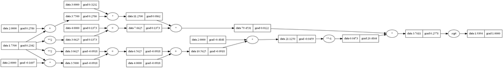

Figure 2 - Depiction of the decomposition of differentials map for Automatic Differentiation (Date: Mar. 2, 2023).

**AD** had to computate 18 partial derivatives to attain that $f^{'}(1.75) = 0.23420$, which is the exact derivative of $f^{'}(x)$ at $x=1.75$. In essence automatic differentiation is a decomposition method that decomposes a function to it element operations, then contructs the partial derivatives that exists in the differential segments between operations.  
Numerical differentiation is based on the finite difference schema which measures the in infinitesimal change in the value of $y$ from one x-value $x_{0}$ to another x-value $x_{1}$, and then normalizes the change over a infinitesimal $h$ which is the difference between $x_{0}$ and $x_{1}$, e.g., $h=x_{1}-x_{0}$.

$$\frac{df}{dx}=\frac{f(x_{1})-f(x_{0})}{x_{1}-x_{0}} \to \frac{df}{dx}=\lim_{h \to 0} \frac{f(x_{0}+h)-f(x_{0})}{x_{0}+h-x_{0}} \to \frac{df}{dx}=\lim_{h \to 0} \frac{f(x_{0}+h)-f(x_{0})}{h}$$

In essence the finite difference schema is a more sophicated slope formulation, which can accurate measure the slope of a function at any given x-value. Though because of the limitation of **Float64**, this schema is an ill-condition schema.

[figure not shown]

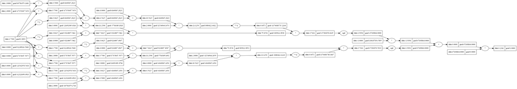

Figure 3 - Depiction of the decomposition of differentials map for Numerical Differentiation (Date: Mar. 2, 2023).

For larger neural networks automatic differentiation (**AD**) and manual differentiation schema are the most appropriate, as both of these schema are computationally stable and well-conditioned algorithms, and both provide a similar degree of accuracy. Though for deep learning models, it would be preferable to utilize an **AD** to computate the partial derivatives needed for backward propagation. A succinct and compendious explanation is that as layers are added to a standard neural network, said standard neural network slowly becomes a deep learning model, and thus the efforts required to derive and computate analytic form solutions to the partial derivatives speedily become a computationally expensive task, and furthermore, depending on the complexity of the loss function there might not exist a close form solution [[18](https://www.math.fsu.edu/~hoeij/issac2017.pdf),[19](https://mathworld.wolfram.com/Closed-FormSolution.html)] to a some or all of the partial derivatives that are needed for backward propagation. In the case that a loss function's partial derivatives does not possess close form solutions, the only amendable approach would be to utilize numerical schema to approximate an analytic solution to each of the aforementioned partial derivatives, so to faliciate backward propagation. As we have shown numerical differentiation is an ill-suited algorithm for this task, though the algorithm could be utilized in certain implementations, it is not an ideal approach to resolving said issue; instead, a **AD** implementation is the solution to said issue, as it can attain the exact solution instead of an approximation and it can automate the backward propagation phase of training. In the case that the loss function's partial derivatives do possess close form solutions, then one would have to be derived the close form solutions by hand, then hardcode each close form solution into the neural networks code architecture, so that it may be executed during each training iteration.  
Nonetheless it is difficult to illustrate in words the complexity of implementing a manual differentiation approach to backward propagation, and so to better illustrate said complexity, we will borrow from *Logistic Regression via FFNN (Feedforward Neural Network)* [[20](https://barryhabsburg.github.io/Logistic_Regression_via_FFNN_version2.html)], in said project, the author's objective was to implement a neural network logistic regression in Python utilizing `numpy` and `scipy.special`; the implementation utilized a manual differentiation approach to backward propagation, and so, it will service as a perfect example. In the following snippet of code contains the backward propagation function from [[20](https://barryhabsburg.github.io/Logistic_Regression_via_FFNN_version2.html)], this snippet perfectly illustrates how one hardcodes the close form solutions of the partial derivative into the neural network code architecure.

```
    def backward_propagation(self,inputs,targets):
        m=inputs.shape[1];

        dZ_2=self.finaloutputs-targets;
        dW_2=(1/m)*np.dot(dZ_2,self.hiddenoutputs.T);
        db_2=(1/m)*(np.sum(dZ_2,axis=1,keepdims=True));
        dZ_1=np.dot(self.who.T,dZ_2)*(1-self.hiddenoutputs**2);
        dW_1=(1/m)*(np.dot(dZ_1,inputs.T));
        db_1=(1/m)*(np.sum(dZ_1,axis=1,keepdims=True));

        self.dW1=dW_1; self.db1=db_1; self.dW2=dW_2; self.db2=db_2;

        pass
```

Figure 4 - Backward propagation function.

Peeling back, but how did the authors derive the close form solutions of the loss function's partial derivatives? And what was the loss function? A logistic regression is useful for estimating probabilities of binary outcomes, or classifying binary outcomes; in the case of [[20](https://barryhabsburg.github.io/Logistic_Regression_via_FFNN_version2.html)] the algorithm was a logistic regression classifier via feedforward neural network (**FFNN**), that was meant to classify credit card applicants for approval or decline for a credit card, from simulated credit card applicant dataset. In either case of likelihood estimate, or classification the loss function for a logistic regression is,

$$loss \: function=\frac{1}{m} \sum_{i}^{m} y_{i} \ln(\sigma(W^{T}x+b))+(1-y_{i})\ln(1-(\sigma(W^{T}x+b))) \; \; \; \; \; \; \; \; \text{(Eq. 1)}$$,

where $\sigma(W^{T}x+b=Final \: outputs)$, and where $W$ is the weight matrix between the hidden layer and output layer and $b$ is the subsequent bias vector and $\sigma()$ is the activation function. Simply a logistic regression is an optimization problem to find the probability value (e.g. critical point), $p$, that maximizes the Bernoulli Maximum Likelihood Estimate (**MLE**) function (Eq. 2) and minimizes the loss function (Eq. 3):

$$MLE= \text{arg} \max_{W \in \R} y_{i} \ln(\sigma(W^{T}x+b))+(1-y_{i})\ln(1-(\sigma(W^{T}x+b))) \; \; \; \; \; \; \; \; \text{(Eq. 2)}$$,

$$loss \: function= \text{arg} \min_{W \in \R} y_{i} \frac{1}{m} \sum_{i}^{m} y_{i} \ln(\sigma(W^{T}x+b))+(1-y_{1})\ln(1-(\sigma(W^{T}x+b))) \; \; \; \; \; \; \; \; \text{(Eq. 3)}$$.

To attain the gradients (e.g. partial derivatives) that maximize the Bernoulli MLE, we take the first-order partial derivative of (Eq. 2),

$$\frac{\partial MLE}{\partial W_{i}}=\frac{\partial MLE}{\partial W_{i}} \bigg( y \ln(\sigma(W^{T}x+b))+(1-y)\ln(1-(\sigma(W^{T}x+b))) \bigg)$$

$$=\frac{\partial MLE}{\partial W_{i}} y \ln(\sigma(W^{T}x+b))+\frac{\partial MLE}{\partial W_{i}}(1-y)\ln(1-(\sigma(W^{T}x+b))) \bigg)$$

$$=\bigg( \frac{y}{\sigma(W^{T}x+b)} - \frac{1-y}{1-\sigma(W^{T}x+b)} \bigg) \frac{\partial}{\partial W_{i}} \sigma(W^{T}x+b)$$

$$=\bigg( \frac{y}{\sigma(W^{T}x+b)} - \frac{1-y}{1-\sigma(W^{T}x+b)} \bigg) \sigma(W^{T}x+b)\big[1-\sigma(W^{T}x+b)\big]x_{i}$$

$$=\Bigg( \frac{y-\sigma(W^{T}x+b)}{\sigma(W^{T}x+b)\big[1-\sigma(W^{T}x+b)\big]} \Bigg) \sigma(W^{T}x+b)\big[1-\sigma(W^{T}x+b)\big]x_{i}$$

$$=\big[ y - \sigma(W^{T}x+b) \big]x_{i}. \; \square$$

After completing manual differentiation and algebraic manipulation we attained the simplified formula (Eq. 4),

$$\frac{\partial MLE}{\partial W_{i}}=\big[ y - \sigma(W^{T}x+b) \big]x_{i}\; \; \; \; \; \; \; \; \text{(Eq. 4)},$$

with this formulation we can attain each of the gradients (e.g. partial derivatives) needed to update the weight matrices and bais vectors.  
A neural network logistic regression contains three layers, one input layer, one hidden layer and one output layer, and hence, two weight matrices and two bais vectors. The first weight matrix is denoted `Wih`, as it is the weight matrix between the input layer and hidden layer; the second weight matrix is denoted `Who` as it is between the hidden layer and output layer. Subsequently, `b1` represents the bias vector corresponding to `Wih`, while `b2` is the bias vector to `Wih`. To devise the backward propagation phase, we need to derive the specific analytic forms to the gradients needed to update the weight matrices and bias vectors, to do so, we will derive the following formulations here,

$$\frac{\partial MLE}{\partial W_{i}}=\big[ y - \sigma(W^{T}x+b) \big]x_{i}$$

$$\to \frac{\partial MLE}{\partial Who_{i}}= \big[ final \: output - target \big] \cdot hidden \: output \; \; \; \; \; \; \; \; \text{(Eq. 5),}$$

$$\to \frac{\partial MLE}{\partial Who_{i}}= \bigg( Who^{T} \cdot \big[ final \: output - target \big] - Who^{T} \cdot \big[ final \: output - target \big] \cdot (hidden \: output)^{2} \bigg) * inputs \; \; \; \; \; \; \; \; \text{(Eq. 6).}$$

To attain the second gradient, $\frac{\partial MLE}{\partial Who_{i}}$, that correspondence to the hidden-output layer weight matrix, $Who$, we need to reformulate (Eq. 4)into what is found in *Figure 4.*, as denoted as `dw_2`. To begin we need to mention that $final \: output$ is the resulting vector that is produced from forward propagation, $final \: output = \sigma(W^{T}x+b)$. The target variable $y$ should be a Bernoulli random vector consisting of $1$s and $0$s, it is normally labelled as $target$ in code implementation. And so to derive the second gradient we need to replace $\sigma(W^{T}x+b)$ with $final \: output$ and replace $y$ with the $target$ variable, then multiplicate the product with the hidden layers output, denoted $hidden \: output$. And as the result of this algebra is an array of gradients, we need to computate the sample average then chose it as the approximation of the second gradient, `dw_2`; the result,

$$\text{dW_2}=\frac{1}{m}\sum_{i}^{m} \big[ final \: output_{i} - target_{i} \big] \cdot hidden \: out_{i};$$

one can observe that $final \: output - target = error$ is the error formula, and that we are calculating the error between $final \: output$ (e.g. score) and $target$. We calculate the magnitude of the error to correct the difference between $final \: output$ (e.g. score) and $target$, we accomplish this by updating the weights and baises of the neural network with the aforementationed sampled average gradients. But we cannot simply apply this error measurement evenly across the hidden and outout layers, we instead need to adjust the error proportionally across hidden and output layers, so target update the weights and bias responsible for the error.  
If $n$ denotes the number of layers that makeup a neural network, then $(n-1)$ represents the number of layers that the error must be proportionally distributed over to correctly explain the errors origin. In our case with a feedforward neural network Logistic regression has three layers, so the error only needs to be distributed over two layers, the one output layer and the one hidden layer. Without further elaboration the first gradient is,

$$\text{dW_1} = \frac{1}{m} \sum_{i}^{m} \big( Who^{T} \cdot \big[ final \: output_{i} - target_{i} \big] - Who^{T} \cdot \big[ final \: output_{i} - target_{i} \big] \cdot \big( hidden \: output_{i} \big)^{2} \big) \cdot inputs_{i},$$

and subsequently, $Who^{T} \cdot \big[ final \: output_{i} - target_{i} \big]$ is the error from the output layer and $\big[ final \: output_{i} - target_{i} \big] \cdot \big( hidden \: output_{i} \big)^{2}$ is the error from the hidden layer; the difference measure is multplied with weight matrix, `Who` which proportions the error between the output and hidden layers based on the connection signal strengths.  
At last it should have become apparent that to implement a backward propagation phase with a manual differentiation schema is not a trivial task, and requires in-depth comprehension of the loss function, and know of how to derive the partial derivatives closed form solutions. For an automatic differentiation schema, only some comprehension of the loss function is required, and its implementation is more streamlined then a manual differentiation schema.  
In the following code block is the slightly modified source code to `Micrograd.nn`: its github can be located here [[11](https://github.com/karpathy/micrograd/blob/master/micrograd/nn.py)]. Andrej Karpathy's heavy use of comprehensive lists made for compact code: the weights and baises are created through comprehensive list and are encapsulated with `Micrograd.Value`. The subsequent generated weights and baises are themselves captured through comprehensive list that makeup the weight matrix and bias vector specific to `Layer(sz[i],sz[i+1],nonlin=i!=len(nouts)-1)`, where `sz[i]` it the prior layer and `sz[i+1]` is the posterior layer. Noting that even weight matrices and bais vectors are subsequently themselves captured inside another comprehensive list, which is parsed alongside $n-1$ storage elements, e.g., $n$ is the number of layers in the neural network.

```python
class Module:
    def zero_grad(self):
        # Resets gradient derivative to zero
        for p in self.parameters():
            p.grad=0;
    def parameters(self):
        return [];
class Neuron(Module):
    def __init__(self,nin,nonlin=True):
        self.weights=[Value(np.random.uniform(-1,1)) for _ in range(nin)];
        self.bias=Value(0);
        self.nonlin=nonlin;
    def __call__(self,x):
        act=sum((wi*xi for wi,xi in zip(self.weights,x)),self.bias);
        return act.tanh() if self.nonlin else act;
    def parameters(self):
        return self.weights+[self.bias];
    def __repr__(self):
        return f"{'tanh()' if self.nonlin else 'Linear'}Neuron({len(self.weights)})";
    pass
class Layer(Module):
    def __init__(self,nin,nout,**kwargs):
        self.neurons=[Neuron(nin,**kwargs) for _ in range(nout)];
    def __call__(self,x):
        out=[n(x) for n in self.neurons];
        return out[0] if len(out) == 1 else out;
    def parameters(self):
        return [p for n in self.neurons for p in n.parameters()];
    def __repr__(self):
        return f"Layer of [{', '.join(str(n) for n in self.neurons)}]";
class MLP(Module):
    def __init__(self,nin,nouts):
        sz=[nin]+nouts;
        self.layers=[Layer(sz[i],sz[i+1],nonlin=i!=len(nouts)-1) for i in range(len(nouts))];
    def __call__(self, x):
        for layer in self.layers:
            x=layer(x);
        return x;
    def parameters(self):
        return [p for layer in self.layers for p in layer.parameters()];
    def __repr__(self):
        return f"MLP of [{', '.join(str(layer) for layer in self.layers)}]";
```

To demonstrate the simplicity of implementing a five layer neural network with **Micrograd**, we included the following snippet of code. The following snippet of code initiates a five layered neural network through `Micrograd.nn` with 901 parameters, with the activation function being set to tanh().

```
    model=MLP(1,[20,20,20,1]);
    print(model);
    print("Model contains "+str(len(model.parameters()))+" parameters.");
```

```
    MLP of [Layer of [tanh()Neuron(1), tanh()Neuron(1), tanh()Neuron(1), tanh()Neuron(1), tanh()Neuron(1), tanh()Neuron(1),  tanh()Neuron(1), tanh()Neuron(1), tanh()Neuron(1), tanh()Neuron(1), tanh()Neuron(1), tanh()Neuron(1), tanh()Neuron(1), tanh()Neuron(1), tanh()Neuron(1), tanh()Neuron(1), tanh()Neuron(1), tanh()Neuron(1), tanh()Neuron(1), tanh()Neuron(1)], Layer of  [tanh()Neuron(20), tanh()Neuron(20), tanh()Neuron(20), tanh()Neuron(20), tanh()Neuron(20), tanh()Neuron(20), tanh()Neuron(20), tanh()Neuron(20), tanh()Neuron(20), tanh()Neuron(20), tanh()Neuron(20), tanh()Neuron(20), tanh()Neuron(20), tanh()Neuron(20), tanh()Neuron(20), tanh()Neuron(20), tanh()Neuron(20), tanh()Neuron(20), tanh()Neuron(20), tanh()Neuron(20)], Layer of [tanh()Neuron(20), tanh()Neuron(20), tanh()Neuron(20), tanh()Neuron(20), tanh()Neuron(20), tanh()Neuron(20), tanh()Neuron(20), tanh()Neuron(20), tanh()Neuron(20), tanh()Neuron(20), tanh()Neuron(20), tanh()Neuron(20), tanh()Neuron(20), tanh()Neuron(20), tanh()Neuron(20), tanh()Neuron(20), tanh()Neuron(20), tanh()Neuron(20), tanh()Neuron(20), tanh()Neuron(20)], Layer of [LinearNeuron(20)]]
    Model contains 901 parameters.
```

Figure 5 - Code to initiate neural network five layers with `Micrograd.nn` and the resulting print to console.

Upon execution, `Micrograd.nn` returns to console the resulting neural network through a sequence of print to console statements. Nevetheless the creation of a five layered neural network is completely automated by `Micrograd.nn`, it contains all the complexity of generating deep learning model, all while lending itself to an automatic differentiation (**AD**) approach to backward propagation.  
Yet again we borrowed from *Logistic Regression via FFNN (Feedforward Neural Network)* [[20](https://barryhabsburg.github.io/Logistic_Regression_via_FFNN_version2.html)], we borrowed the logistic regression classifier's algorithm, so to make a comparison between it and a neural network model generated with **Micrograd**; the simulated credit card applicant dataset from [[20](https://barryhabsburg.github.io/Logistic_Regression_via_FFNN_version2.html)], that was used for classification was also borrowed, but was not used as the training or testing dataset. Instead we imported the simulated credit card applicant dataset, and generated a new simulated dataset through pseudo-random number sampling. Subsequently imported the simulated credit card applicant dataset with `Pandas.read_csv` as a dataframe named `train_df2`.

```python
train_df=pd.read_csv("Training_R-197135_Candidate_Attach_1_JDSE_SRF_456.csv.csv")
train_df
```

|  | tot_balance | avg_bal_cards | credit_age | credit_age_good_account | credit_card_age | num_acc_30d_past_due_12_months | num_acc_30d_past_due_6_months | num_mortgage_currently_past_due | tot_amount_currently_past_due | num_inq_12_month | ... | num_card_12_month | num_auto_ 36_month | uti_open_card | pct_over_50_uti | uti_max_credit_line | pct_card_over_50_uti | ind_XYZ | rep_income | rep_education | Def_ind |
| --- | --- | --- | --- | --- | --- | --- | --- | --- | --- | --- | --- | --- | --- | --- | --- | --- | --- | --- | --- | --- | --- |
| 0 | 102956.11010 | 14819.057400 | 238 | 104 | 264 | 0 | 0 | 0 | 0.000000 | 0 | ... | 1 | 0 | 0.366737 | 0.342183 | 0.513934 | 0.550866 | 0 | 118266.32130 | college | 0 |
| 1 | 132758.72580 | 18951.934550 | 384 | 197 | 371 | 0 | 0 | 0 | 0.000000 | 0 | ... | 0 | 0 | 0.490809 | 0.540671 | 0.418016 | NaN | 0 | 89365.05765 | college | 0 |
| 2 | 124658.91740 | 15347.929690 | 277 | 110 | 288 | 0 | 0 | 0 | 0.000000 | 0 | ... | 0 | 0 | 0.359074 | 0.338560 | 0.341627 | 0.451417 | 0 | 201365.12130 | college | 0 |
| 3 | 133968.53690 | 14050.713340 | 375 | 224 | 343 | 0 | 0 | 0 | 0.000000 | 2 | ... | 1 | 0 | 0.700379 | 0.683589 | 0.542940 | 0.607843 | 0 | 191794.48550 | college | 0 |
| 4 | 143601.80170 | 14858.515270 | 374 | 155 | 278 | 0 | 0 | 0 | 0.000000 | 0 | ... | 0 | 0 | 0.647351 | 0.510812 | 0.632934 | 0.573680 | 0 | 161465.36790 | graduate | 0 |
| ... | ... | ... | ... | ... | ... | ... | ... | ... | ... | ... | ... | ... | ... | ... | ... | ... | ... | ... | ... | ... | ... |
| 19995 | 89665.13930 | 11521.159950 | 319 | 139 | 363 | 0 | 0 | 0 | 0.000000 | 0 | ... | 0 | 0 | 0.535628 | 0.634712 | 0.527230 | 0.602345 | 0 | NaN | high_school | 0 |
| 19996 | 136211.63530 | 17977.054130 | 297 | 137 | 273 | 0 | 0 | 0 | 0.000000 | 2 | ... | 0 | 0 | 0.464774 | 0.450030 | 0.545108 | NaN | 1 | NaN | high_school | 0 |
| 19997 | 110721.87650 | 13316.820540 | 304 | 151 | 257 | 0 | 0 | 0 | 0.000000 | 0 | ... | 0 | 0 | 0.264544 | 0.340289 | 0.412155 | NaN | 0 | 157706.15810 | college | 0 |
| 19998 | 96742.36371 | 11743.262370 | 275 | 141 | 294 | 2 | 1 | 1 | 3009.387661 | 0 | ... | 0 | 0 | 0.609226 | 0.582007 | 0.301612 | 0.697052 | 1 | 97387.97414 | college | 1 |
| 19999 | 107338.82070 | 7942.952546 | 325 | 195 | 302 | 0 | 0 | 0 | 0.000000 | 0 | ... | 0 | 0 | 0.358067 | 0.435511 | 0.349246 | NaN | 0 | 165447.16380 | college | 0 |

20000 rows × 21 columns

```python
train_df2=train_df.dropna();
a=list(train_df2['rep_education'])
b=[];

for i in range(len(a)):
    if a[i]=='Other':
        b.append(1);
    elif a[i]=='high_school':
        b.append(2);
    elif a[i]=='college':
        b.append(3);
    elif a[i]=='graduate':
        b.append(4);
    else:
        b.append(0);

train_df2[train_df2.columns[19]]=b;
print('Number of duplicate accounts: '+str(sum(train_df2.duplicated()))); # Number of duplicate obs.
print(" ");
print("Size of train_df: " +str(train_df.shape));
print("Size of train_df2 "+str(train_df2.shape));
print(" ");
print("Column names:");
print(list(train_df2.columns));
```

```
Number of duplicate accounts: 0

Size of train_df: (20000, 21)
Size of train_df2 (16653, 21)

Column names:
['tot_balance', 'avg_bal_cards', 'credit_age', 'credit_age_good_account', 'credit_card_age', 'num_acc_30d_past_due_12_months', 'num_acc_30d_past_due_6_months', 'num_mortgage_currently_past_due', 'tot_amount_currently_past_due', 'num_inq_12_month', 'num_card_inq_24_month', 'num_card_12_month', 'num_a…
```

[output not shown]

Cleaned the subsequent dataframe in the same way as [[20](https://barryhabsburg.github.io/Logistic_Regression_via_FFNN_version2.html)], then renamed the cleaned dataframe to `train_df2`. To gain a deeper comprehension of the random vectors that composed `train_df2`, we isolated each of the random vectors and ploted each of random vectors onto a histogram - so to discern the statistical characteristis; e.g., central tendency, variability, skewness and subsequentially shape of distribution. An example is followed in the code block below, with `train_df2["tot_balance"]`.

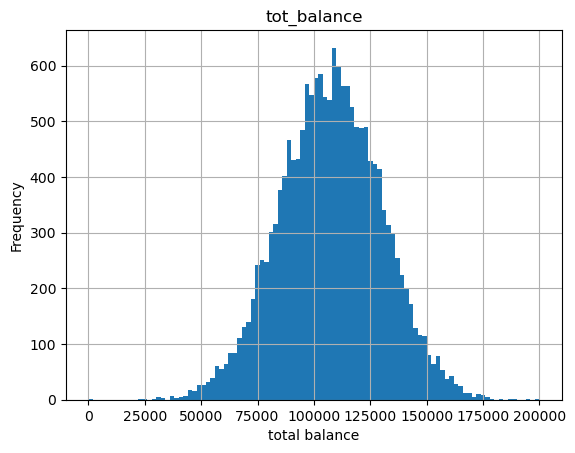

```python
train_df2["tot_balance"].hist(bins=100);
plt.title("tot_balance");
plt.xlabel("total balance");
plt.ylabel("Frequency");
plt.show();
```

| Normal distributed random vectors: | **'tot_balance'** | **'avg_bal_cards'** | **'credit_age'** |
| --- | --- | --- | --- |
|  | **'credit_age_good_account'** | **'credit_card_age'** | **'uti_open_card'** |
|  | **'pct_over_50_uti'** | **'uti_max_credit_line'** | **'pct_card_over_50_uti'** |

| Log-Normal distributed random vectors: | **'tot_amount_currently_past_due'** |
| --- | --- |

| Bernoulli distributed random vectors: | **'num_auto_ 36_month'** | 'num_acc_30d_ past_due_6_months' | 'num_mortgage_ currently_past_due' |
| --- | --- | --- | --- |
|  | **'ind_XYZ'** | **'Def_ind'** |  |

| Indictor variables: | **'num_card_inq_24_month'** | **'num_card_12_month'** | **'num_inq_12_month'** |
| --- | --- | --- | --- |
|  | 'num_acc_30d_past _due_12_months' | **'rep_education'** |  |

There will not be a complete and exhaustive explanation for each of the pseudo-random sampling for each random vector, but there will be a selection of explanation of the most pertain sampling processes.  
Firstly used `np.mean()` and `np.std()` to attain the mean (e.g. $\mu_{tot \: balance}$) and standard deviation (e.g. $\sigma_{tot \: balance}$) of the original random vector, `tot_balance`. After, we used `np.random.randn(len(tot_balance))` to return a standard normal random vector, $Z\mathcal{N}(\mu=0,\sigma^{2}=1)$ with length `len(tot_balance)`, then used the following transformation,

$$X=\mu+\sigma*Z \to X = \mu_{tot \: balance} + \sigma_{tot \: balance} \cdot \mathcal{N}(\mu=0,\sigma^{2}=1) \to X = \mathcal{N}(\mu=\mu_{tot \: balance},\sigma^{2}=\sigma_{tot \: balance}^{2}),$$

this resulted in a normal random vector with almost the same statistical characteristics as the original random vector.

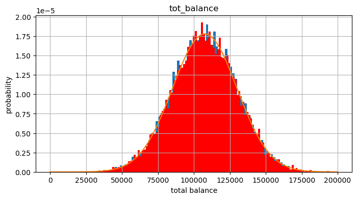

```
tot_balance
Mean: 107503.36884985829
Std: 22428.05179380614

sim_tot_balance
Mean: 107514.20903717751
Std: 22484.04427595301
```

```python
plt.rcParams["figure.figsize"]=[8,4];

tot_balance=train_df2["tot_balance"];
mean=np.mean(tot_balance); sd=np.std(tot_balance);
maximum=np.max(tot_balance); minimum=np.min(tot_balance);
sim_tot_balance=mean+sd*np.random.randn(len(tot_balance));
sim_mean=np.mean(sim_tot_balance); sim_sd=np.std(sim_tot_balance);

count,bins,ignored=plt.hist(tot_balance, 120, density=True);
count,bins,ignored=plt.hist(sim_tot_balance, 120, density=True, color='red');
x_axis=np.arange(minimum,maximum,0.01);
plt.plot(x_axis,norm.pdf(x_axis,mean,sd));
plt.title("tot_balance");
plt.xlabel("total balance");
plt.ylabel("probability");
plt.grid();
plt.show();
print("tot_balance");
print("Mean: " + str(mean));
print("Std: " + str(sd));
print(" ");
print("sim_tot_balance");
print("Mean: " + str(sim_mean));
print("Std: " + str(sim_sd));
```

After plotting `'credit_age_good_account'` in a histogram plot, it was discovered that `'credit_age_good_account'` had a normal distribution but had some noise random variable added to it. As noisy data is not particularly useful, we did not decide to add an additional noise vector to `sim_credit_age_good_account`. The same pseudo-random number sampling process was used here to sample for `sim_credit_age_good_account`, the same degree of accuracy was achieved as previously.

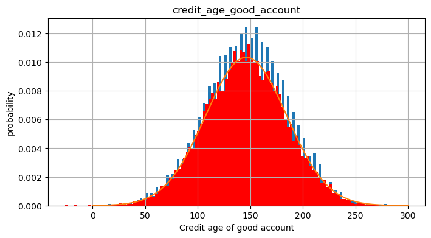

```
credit_age_good_account
Mean: 146.15036329790428
Std: 38.61890280075336

sim_credit_age_good_account
Mean: 145.54188889738109
Std: 38.32859022430993
```

```python
credit_age_good_account=train_df2["credit_age_good_account"];
mean=np.mean(credit_age_good_account); sd=np.std(credit_age_good_account);
maximum=np.max(credit_age_good_account); minimum=np.min(credit_age_good_account);
sim_credit_age_good_account=mean+sd*np.random.randn(len(credit_age_good_account));
sim_mean=np.mean(sim_credit_age_good_account); sim_sd=np.std(sim_credit_age_good_account);


count,bins,ignored=plt.hist(credit_age_good_account, 120, density=True);
count,bins,ignored=plt.hist(sim_credit_age_good_account, 120, density=True, color='red');
x_axis=np.arange(minimum,maximum,0.01);
plt.plot(x_axis,norm.pdf(x_axis,mean,sd));
plt.title("credit_age_good_account");
plt.xlabel("Credit age of good account");
plt.ylabel("probability");
plt.grid();
plt.show();
print("credit_age_good_account");
print("Mean: " + str(mean));
print("Std: " + str(sd));
print(" ")
print("sim_credit_age_good_account");
print("Mean: " + str(sim_mean));
print("Std: " + str(sim_sd));
```

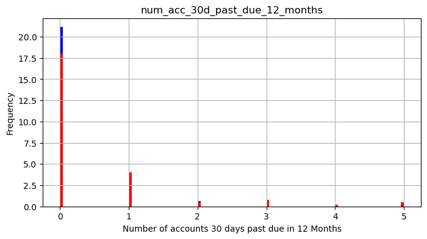

```
num_acc_30d_past_due_12_months
Zero accounts: 14655
One account: 1474
two accounts: 430
three account: 84
four account: 7
five account: 3

num_acc_30d_past_due_12_months
sim_num_acc_30d_past_due_12_months
Zero accounts: 12498
One account: 2764
two accounts: 359
three account: 531
four account: 158
five account: 343
```

```python
num_acc_30d_past_due_12_months=train_df2["num_acc_30d_past_due_12_months"];
a=[random.randint(0,1) for _ in range(len(num_acc_30d_past_due_12_months))];
b=[ ai-1 if ai-1 == random.randint(0,1) else ai for ai in a];
c=[ bi+1 if bi-1 == random.randint(0,2) else bi for bi in b];
d=[ ci+1 if ci-2 == random.randint(0,1) else ci for ci in c];
e=[ di+2 if di-3 == random.randint(0,1) else di for di in d];
sim_num_acc_30d_past_due_12_months=[ di+1 if di-2 == random.randint(0,1) else di for di in e];

count,bins,ignored=plt.hist(num_acc_30d_past_due_12_months, 120, density=True,color='blue');
count,bins,ignored=plt.hist(sim_num_acc_30d_past_due_12_months, 120, density=True, color='red');
plt.title("num_acc_30d_past_due_12_months");
plt.xlabel("Number of accounts 30 days past due in 12 Months");
plt.ylabel("Frequency");
plt.grid();
plt.show();
print("num_acc_30d_past_due_12_months");
print("Zero accounts: " + str(sum(train_df2["num_acc_30d_past_due_12_months"]==0)));
print("One account: " + str(sum(train_df2["num_acc_30d_past_due_12_months"]==1)));
print("two accounts: " + str(sum(train_df2["num_acc_30d_past_due_12_months"]==2)));
print("three account: " + str(sum(train_df2["num_acc_30d_past_due_12_months"]==3)));
print("four account: " + str(sum(train_df2["num_acc_30d_past_due_12_months"]==4)));
print("five account: " + str(sum(train_df2["num_acc_30d_past_due_12_months"]==5)));
print(" ");
print("num_acc_30d_past_due_12_months");
temp=pd.DataFrame({ 'counts':sim_num_acc_30d_past_due_12_months});
print("sim_num_acc_30d_past_due_12_months");
print("Zero accounts: " + str(sum(temp["counts"]==0)));
print("One account: " + str(sum(temp["counts"]==1)));
print("two accounts: " + str(sum(temp["counts"]==2)));
print("three account: " + str(sum(temp["counts"]==3)));
print("four account: " + str(sum(temp["counts"]==4)));
print("five account: " + str(sum(temp["counts"]==5)));
```

A pseduo-random number (**PRN**) sampler for Bernoulli random vector does exist, and there is a convention function in the form of `scipy.stats.bernoulli` [[21](https://docs.scipy.org/doc/scipy/reference/generated/scipy.stats.bernoulli.html)]; we decided to re-use our crude **PRN** sampler algorihtm to generate a new random vector for `ind_XYZ`. Nonetheless in this case, the crude **PRN** algorithm achieved a high degree of accuracy.

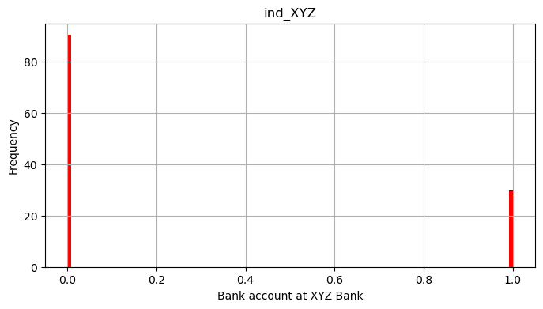

```
ind_XYZ
Have an account: 12512
Do not have an account: 4141

sim_ind_XYZ
sim_num_acc_30d_past_due_12_months
Have an account: 12542
Do not have an account: 4111
```

```python
ind_XYZ=train_df2["ind_XYZ"];
a=[random.randint(0,1) for _ in range(len(ind_XYZ))];
b=[ ai-1 if ai-1 == random.randint(0,1) else ai for ai in a];
c=[ 1 if ai == random.randint(0,1) else 0 for ai in b];
sim_ind_XYZ=[ di-1 if di-1 == random.randint(0,1) else di for di in c];


count,bins,ignored=plt.hist(ind_XYZ, 120, density=True, color='blue');
count,bins,ignored=plt.hist(sim_ind_XYZ, 120, density=True, color='red');
plt.title("ind_XYZ");
plt.xlabel("Bank account at XYZ Bank");
plt.ylabel("Frequency");
plt.grid();
plt.show();
print("ind_XYZ");
print("Have an account: " + str(sum(train_df2["ind_XYZ"]==0)));
print("Do not have an account: " + str(sum(train_df2["ind_XYZ"]==1)));
print(" ");
print("sim_ind_XYZ");
temp=pd.DataFrame({ 'counts':sim_ind_XYZ});
print("sim_num_acc_30d_past_due_12_months");
print("Have an account: " + str(sum(temp["counts"]==0)));
print("Do not have an account: " + str(sum(temp["counts"]==1)));
```

A pseudo-random number log-normal sampler from `numpy`, `np.random.lognormal()` with the following statistical characteristics, $\mu = 8.19$ and $\lambda = 8/10$ was used to generate the new log-normal random vector.

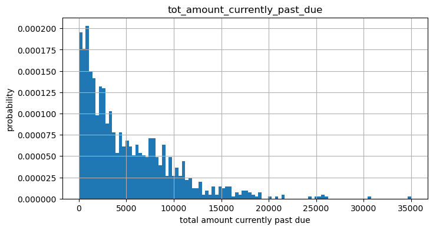

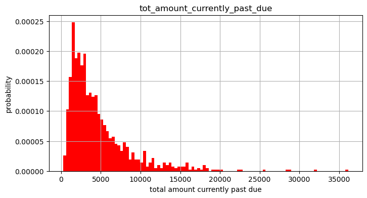

```
ind_XYZ
Mean: 5041.243208355967
Std: 4703.343851176609

sim_ind_XYZ
Mean: 4641.173686991248
Std: 4011.5489408282906
```

```python
t=train_df2[train_df2["tot_amount_currently_past_due"]>0.0]
tot_amount_currently_past_due=t["tot_amount_currently_past_due"];
mean=np.mean(tot_amount_currently_past_due); sd=np.std(tot_amount_currently_past_due);
maximum=np.max(tot_amount_currently_past_due); minimum=np.min(tot_amount_currently_past_due);
sim_tot_amount_currently_past_due=np.random.lognormal(8.19,8/10,len(tot_amount_currently_past_due));
sim_mean=np.mean(sim_tot_amount_currently_past_due); sim_sd=np.std(sim_tot_amount_currently_past_due);

count,bins,ignored=plt.hist(tot_amount_currently_past_due, 100, density=True);
plt.title("tot_amount_currently_past_due");
plt.xlabel("total amount currently past due");
plt.ylabel("probability");
plt.grid();
plt.show();
count,bins,ignored=plt.hist(sim_tot_amount_currently_past_due, 100, density=True, color='red');
plt.title("tot_amount_currently_past_due");
plt.xlabel("total amount currently past due");
plt.ylabel("probability");
plt.grid();
plt.show()
print("ind_XYZ");
print("Mean: " + str(mean));
print("Std: " + str(sd));
print(" ");
print("sim_ind_XYZ");
print("Mean: " + str(sim_mean));
print("Std: " + str(sim_sd));
```

Assembling the collection of **PRN** algorithms together, we were able to generate a new simulated credit card applicant dataset, `df3`; though we did on-purpose remove certain input variables, as a way to keep the matrix condition of the dataset low - so to maintain a manageable computational cost to train the coming neural networks.

```python
dataSize=500;

tot_balance=train_df2["tot_balance"];
mean=np.mean(tot_balance); sd=np.std(tot_balance);
maximum=np.max(tot_balance); minimum=np.min(tot_balance);
sim_tot_balance=mean+sd*np.random.randn(dataSize);

avg_bal_cards=train_df2["avg_bal_cards"]
mean=np.mean(avg_bal_cards); sd=np.std(avg_bal_cards);
maximum=np.max(avg_bal_cards); minimum=np.min(avg_bal_cards);
sim_avg_bal_cards=mean+sd*np.random.randn(dataSize);

credit_age=train_df2["credit_age"];
mean=np.mean(credit_age); sd=np.std(credit_age);
maximum=np.max(credit_age); minimum=np.min(credit_age);
sim_credit_age=mean+sd*np.random.randn(dataSize);

credit_age_good_account=train_df2["credit_age_good_account"];
mean=np.mean(credit_age_good_account); sd=np.std(credit_age_good_account);
maximum=np.max(credit_age_good_account); minimum=np.min(credit_age_good_account);
sim_credit_age_good_account=mean+sd*np.random.randn(dataSize);

# num_acc_30d_past_due_12_months
num_acc_30d_past_due_12_months=train_df2["num_acc_30d_past_due_12_months"];
a=[random.randint(0,1) for _ in range(dataSize)];
b=[ ai-1 if ai-1 == random.randint(0,1) else ai for ai in a];
c=[ bi+1 if bi-1 == random.randint(0,2) else bi for bi in b];
d=[ ci+1 if ci-2 == random.randint(0,1) else ci for ci in c];
e=[ di+2 if di-3 == random.randint(0,1) else di for di in d];
sim_num_acc_30d_past_due_12_months=[ di+1 if di-2 == random.randint(0,1) else di for di in e];

rep_income=train_df2["rep_income"];
mean=np.mean(rep_income); sd=np.std(rep_income);
maximum=np.max(rep_income); minimum=np.min(rep_income);
sim_rep_income=mean+sd*np.random.randn(dataSize);

num_acc_30d_past_due_6_months=train_df2["num_acc_30d_past_due_6_months"];
a=[random.randint(0,1) for _ in range(dataSize)];
b=[ ai-1 if ai-1 == random.randint(0,1) else ai for ai in a];
c=[ ci-1 if ci-1 == random.randint(0,1) else ci for ci in b];
sim_num_acc_30d_past_due_6_months=[ bi-1 if bi-1 == random.randint(0,1) else bi for bi in c];

num_mortgage_currently_past_due=train_df2["num_mortgage_currently_past_due"];
a=[random.randint(0,1) for _ in range(dataSize)];
b=[ ai-1 if ai-1 == random.randint(0,1) else ai for ai in a];
c=[ ci-1 if ci-1 == random.randint(0,1) else ci for ci in b];
sim_num_mortgage_currently_past_due=[ bi-1 if bi-1 == random.randint(0,1) else bi for bi in c];

t=train_df2[train_df2["tot_amount_currently_past_due"]>0.0]
tot_amount_currently_past_due=t["tot_amount_currently_past_due"];
sim_tot_amount_currently_past_due=np.random.lognormal(8,8/10,dataSize);

ind_XYZ=train_df2["ind_XYZ"];
a=[random.randint(0,1) for _ in range(dataSize)];
b=[ ai-1 if ai-1 == random.randint(0,1) else ai for ai in a];
sim_ind_XYZ=[ ci-1 if ci-1 == random.randint(0,1) else ci for ci in b];

#pct_card_over_50_uti=train_df2["pct_card_over_50_uti"];
#mean=np.mean(pct_card_over_50_uti); sd=np.std(pct_card_over_50_uti);
#maximum=np.max(pct_card_over_50_uti); minimum=np.min(pct_card_over_50_uti);
#sim_pct_card_over_50_uti=mean+sd*np.random.randn(dataSize);


debtToIncomeratio=sim_tot_balance/(sim_rep_income);
defaulted=[1 if i > 0.9 else 0 for i in debtToIncomeratio];

num_default=np.array(sim_num_acc_30d_past_due_12_months)+np.array(sim_num_acc_30d_past_due_6_months)+np.array(sim_num_mortgage_currently_past_due);
default_new=[ 1 if i >= 4 else 0 for i in num_default];
defaulted_full=np.array(default_new)+np.array(defaulted);
defaulted_full=[ 1 if i == 1 or i==2 else 0 for i in defaulted_full]

#sim_def_ind=np.array([random.randint(0, 1) for _ in range(dataSize)]);


df3=pd.DataFrame({'tot_balance': sim_tot_balance,'avg_bal_cards': sim_avg_bal_cards, 'credit_age': sim_credit_age
                  ,'credit_age_good_account':sim_credit_age_good_account
                  , 'num_acc_30d_past_due_12_months': sim_num_acc_30d_past_due_12_months
                  , 'num_acc_30d_past_due_6_months': sim_num_acc_30d_past_due_6_months
                  , 'num_mortgage_currently_past_due': sim_num_mortgage_currently_past_due
                  , 'tot_amount_currently_past_due': sim_tot_amount_currently_past_due
                  , 'ind_XYZ': sim_ind_XYZ
                  , 'rep_income': sim_rep_income,'Defaulted': defaulted_full })

print("Non-Defaulted: " + str(sum(df3["Defaulted"]==0)))
print("Defaulted: " + str(sum(df3["Defaulted"]==1)))

df3
```

```
Non-Defaulted: 416
Defaulted: 84
```

|  | tot_balance | avg_bal_cards | credit_age | credit_age_good_account | num_acc_30d_past_due_12_months | num_acc_30d_past_due_6_months | num_mortgage_currently_past_due | tot_amount_currently_past_due | ind_XYZ | rep_income | Defaulted |
| --- | --- | --- | --- | --- | --- | --- | --- | --- | --- | --- | --- |
| 0 | 140456.576250 | 13824.903059 | 352.221213 | 174.523521 | 0 | 0 | 0 | 401.377371 | 0 | 80242.653958 | 1 |
| 1 | 126120.371698 | 9903.954209 | 384.352087 | 163.660158 | 0 | 0 | 0 | 3661.213618 | 0 | 167459.333794 | 0 |
| 2 | 81737.589281 | 13687.200227 | 264.631923 | 131.836473 | 0 | 0 | 0 | 12237.484675 | 0 | 226661.251838 | 0 |
| 3 | 102946.916678 | 11253.636585 | 308.885163 | 174.461665 | 1 | 0 | 0 | 1665.550339 | 0 | 233133.495151 | 0 |
| 4 | 103519.428954 | 10552.725077 | 381.662197 | 114.220516 | 0 | 0 | 0 | 1644.383520 | 1 | 214827.592118 | 0 |
| ... | ... | ... | ... | ... | ... | ... | ... | ... | ... | ... | ... |
| 495 | 98563.134029 | 13463.024815 | 272.483427 | 83.605841 | 0 | 0 | 0 | 1969.091648 | 0 | 154374.120595 | 0 |
| 496 | 110788.057162 | 12481.406418 | 384.207932 | 131.144301 | 0 | 0 | 0 | 605.053944 | 0 | 222393.634415 | 0 |
| 497 | 87360.804270 | 11802.121205 | 291.119687 | 198.394956 | 0 | 0 | 0 | 2184.219377 | 0 | 147087.456213 | 0 |
| 498 | 71720.166969 | 9804.131251 | 299.377163 | 162.078058 | 1 | 0 | 0 | 4658.189289 | 1 | 112002.960819 | 0 |
| 499 | 106337.131360 | 10691.450219 | 260.155874 | 117.821163 | 0 | 0 | 0 | 2867.261301 | 1 | 122816.092700 | 0 |

500 rows × 11 columns

To feed the simulate credit card applicant dataset, `df3`, into the feedforward Neural Network (**FFNN**), the dataset was split between the feature variables denoted as `X` and the target variable denoted as `Y`. In addition as the **FFNN** cannot handle data in the `pandas.core.frame.DataFrame` format, the feature variables dataset `X` and target variable dataset `Y` had to be converted to `numpy.ndarray` format, which is a data format that the **FFNN** can handle, e.g. a data format that it can perform calcalutations upon, and thus use to train itself.

```python
labelList=df3.columns[0:10]; X=df3[labelList]; Y=df3["Defaulted"];
X=X.to_numpy(); Y=Y.to_numpy();
```

Subsequentially re-initiated the neural network class function, so to make sure, all changes to the function were executed; followed with the creation of a four-layered **FFNN** model, named `model`.

```python
class Module:
    def zero_grad(self):
        # Resets gradient derivative to zero
        for p in self.parameters():
            p.grad=0;
    def parameters(self):
        return [];
class Neuron(Module):
    def __init__(self,nin,nonlin=True):
        self.weights=[Value(np.random.uniform(-1,1)) for _ in range(nin)];
        self.bias=Value(0);
        self.nonlin=nonlin;
    def __call__(self,x):
        act=sum((wi*xi for wi,xi in zip(self.weights, x)),self.bias);
        #return act;
        return act.tanh() if self.nonlin else act;
    def parameters(self):
        return self.weights+[self.bias];
    def __repr__(self):
        return f"{'tanh()' if self.nonlin else 'Linear'}Neuron({len(self.weights)})";
    pass
class Layer(Module):
    def __init__(self,nin,nout,**kwargs):
        self.neurons=[Neuron(nin,**kwargs) for _ in range(nout)];
    def __call__(self,x):
        out=[n(x) for n in self.neurons];
        return out[0] if len(out) == 1 else out;
    def parameters(self):
        return [p for n in self.neurons for p in n.parameters()];
    def __repr__(self):
        return f"Layer of [{', '.join(str(n) for n in self.neurons)}]";
class MLP(Module):
    def __init__(self,nin,nouts):
        sz=[nin]+nouts;
        self.layers=[Layer(sz[i],sz[i+1],nonlin=i!=len(nouts)-1) for i in range(len(nouts))];
    def __call__(self, x):
        for layer in self.layers:
            x=layer(x);
        return x;
    def parameters(self):
        return [p for layer in self.layers for p in layer.parameters()];
    def __repr__(self):
        return f"MLP of [{', '.join(str(layer) for layer in self.layers)}]";
```

```python
# initialize a model
model=MLP(10,[25,25,1]); # 4-layer neural network
print(model);
print("number of parameters", len(model.parameters()));
```

```
MLP of [Layer of [tanh()Neuron(10), tanh()Neuron(10), tanh()Neuron(10), tanh()Neuron(10), tanh()Neuron(10), tanh()Neuron(10), tanh()Neuron(10), tanh()Neuron(10), tanh()Neuron(10), tanh()Neuron(10), tanh()Neuron(10), tanh()Neuron(10), tanh()Neuron(10), tanh()Neuron(10), tanh()Neuron(10), tanh()Neuron…
number of parameters 951
```

For different data types requires different loss functions, and in our case the target variable is a Bernoulli random vector, so the best loss function is the cross-entropy loss function, which is know in mathematics/statistics as the Bernoulli maximum likelihood estimate function (**MLE**). In the following code block contains the Python function named, `loss`; it the function that is responsible for the execution of forward propagation, calculation of the total loss and its L2-norm regularization, and the calculation of the current accuracy of the model. Upon execution `loss` returns a print to console statement contianing the models current `total_loss` and `accuracy`.

```python
def loss(X,Y):
    # Forward propagation
    inputs = [list(map(Value, xrow)) for xrow in X]
    scores=list(map(model,inputs))
    scores=[((scorei)).sigmoid() for scorei in scores]

    # Bernoulli MLE loss function
    losses=[yi*(scorei.log())+(1-yi)*((1-scorei).log()) for yi,scorei in zip(Y,scores)];
    data_loss=sum(losses)*(1.0/len(losses));
    # L2-norm regularization
    alpha=(1/len(model.parameters()));
    reg_loss=alpha * sum((p*p.data for p in model.parameters()));
    total_loss=data_loss+reg_loss;

    # also get accuracy
    predictions=[scorei.data > 0.5 for scorei in scores];
    acc=[predi==yi.data for predi,yi in zip(predictions,Y)];
    accuracy=sum(acc)/len(acc);
    return total_loss,accuracy;

total_loss,acc=loss(X,Y);
print(total_loss,acc);
```

```
Value(data=-2.5502958276408814, grad=0) 0.168
```

Have not defined the recursion, so the in the following code block, is the code to recursively executive the three phases of training: forward propagation, backward propagation and parameter updating. Nevertheless the five-hundred observation `df3` dataset was utilized in the training of the four-layered neural network generated by **Micrograd**.

```python
# optimization
for k in range(50):

    # forward propagation - returns total_loss and accuracy
    total_loss,acc=loss(X,Y);

    # backward propagation: reset gradients and generates new gradients
    model.zero_grad();
    total_loss.backward();

    # updates the parameters with Gradient Descent
    learning_rate=0.7
    for p in model.parameters():
        p.data-=learning_rate*p.grad;

    if k % 1 == 0:
        print(f"step {k} loss {total_loss.data}, accuracy {acc*100}%")
```

```
step 0 loss -2.5502958276408814, accuracy 16.8%
step 1 loss -1.5696244646986208, accuracy 83.2%
step 2 loss -1.0348112955624775, accuracy 83.2%
step 3 loss -0.5343441917862877, accuracy 83.2%
step 4 loss -0.08573477350277542, accuracy 83.2%
step 5 loss 0.049364492690614825, accuracy 93.4%
step 6 loss 0.049397316342825404, accuracy 83.2%
step 7 loss 0.11555811965632098, accuracy 95.6%
step 8 loss 0.11832107133497854, accuracy 93.4%
step 9 loss 0.14720625819055178, accuracy 96.39999999999999%
step 10 loss 0.15412478380861874, accuracy 96.39999999999999%
step 11 loss 0.16012998171954337, accuracy 96.39999999999999%
step 12 loss 0.16343531606915174, accuracy 96.39999999999999%
step 13 loss 0.16586244082270032, accuracy 96.39999999999999%
step 14 loss 0.16776266989458238, accuracy 96.39999999999999%
step 15 loss 0.16927806274022028, accuracy 96.39999999999999%
step 16 loss 0.17050180231314707, accuracy 96.39999999999999%
step 17 loss 0.1714836736296445, accuracy 96.39999999999999%
step 18 loss 0.17226617023242075, accuracy 96.39999999999999%
step 19 loss 0.17288117144646806, accuracy 96.39999999999999%
step 20 loss 0.17335472957027592, accuracy 96.39999999999999%
step 21 loss 0.1737079426574257, accuracy 96.39999999999999%
step 22 loss 0.17395825068933732, accuracy 96.39999999999999%
step 23 loss 0.17412021367637137, accuracy 96.39999999999999%
step 24 loss 0.174206116665363, accuracy 96.39999999999999%
step 25 loss 0.17422640539034548, accuracy 96.39999999999999%
step 26 loss 0.17419001071204876, accuracy 96.39999999999999%
step 27 loss 0.17410459430657263, accuracy 96.39999999999999%
step 28 loss 0.17397674073849398, accuracy 96.39999999999999%
step 29 loss 0.17381211275274752, accuracy 96.39999999999999%
step 30 loss 0.17361558071733882, accuracy 96.39999999999999%
step 31 loss 0.17339133297067438, accuracy 96.39999999999999%
step 32 loss 0.17314297114924967, accuracy 96.39999999999999%
step 33 loss 0.17287359299588148, accuracy 96.39999999999999%
step 34 loss 0.1725858643038954, accuracy 96.39999999999999%
step 35 loss 0.17228208124045347, accuracy 96.39999999999999%
step 36 loss 0.17196422410517742, accuracy 96.39999999999999%
step 37 loss 0.1716340034919438, accuracy 96.39999999999999%
step 38 loss 0.17129289976451245, accuracy 96.39999999999999%
step 39 loss 0.1709421966999456, accuracy 96.39999999999999%
step 40 loss 0.17058301008835836, accuracy 96.39999999999999%
step 41 loss 0.17021631200359502, accuracy 96.39999999999999%
step 42 loss 0.16984295138097108, accuracy 96.39999999999999%
step 43 loss 0.1694636714598665, accuracy 96.39999999999999%
step 44 loss 0.16907912457402907, accuracy 96.39999999999999%
step 45 loss 0.16868988470352989, accuracy 96.39999999999999%
step 46 loss 0.16829645814037378, accuracy 96.39999999999999%
step 47 loss 0.16789929256545102, accuracy 96.39999999999999%
step 48 loss 0.1674987847874862, accuracy 96.39999999999999%
step 49 loss 0.16709528735441861, accuracy 96.39999999999999%
```

```
Accuracy: 0.964


Recall: 0.9649532710280374
Precision: 0.9927884615384616
Accuracy: 0.964
F-measure: 0.9786729857819906
```

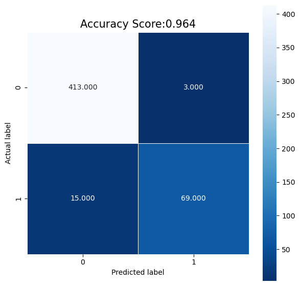

```python
inputs = [list(map(Value, xrow)) for xrow in X];
scores=list(map(model,inputs));
scores=[((scorei)).sigmoid() for scorei in scores];
predictions=[scorei.data > 0.5 for scorei in scores];
acc=[predi==yi.data for predi,yi in zip(predictions,Y)];
accuracy=sum(acc)/len(acc);
print("Accuracy: " + str(accuracy));
print(" ")
cm=metrics.confusion_matrix(Y,predictions);
plt.figure(figsize=(7,7));
seaborn.heatmap(cm,annot=True,fmt=".3f",
            linewidths=.5,square=True,cmap='Blues_r');
plt.ylabel('Actual label');
plt.xlabel('Predicted label');
all_sample_title='Accuracy Score:{0}'.format(accuracy);
plt.title(all_sample_title,size=15);
print(" ")
recall=cm[0,0]/(cm[0,0]+cm[1,0]);
precision=cm[0,0]/(cm[0,0]+cm[0,1]);
accuracy=(cm[0,0]+cm[1,1])/(cm[0,0]+cm[0,1]+cm[1,0]+cm[1,1]);
F_measure=(2*recall*precision)/(recall+precision);
print("Recall: "+str(recall));
print("Precision: "+str(precision));
print("Accuracy: "+str(accuracy));
print("F-measure: "+str(F_measure));
```

The four-layered neural network generated by **Micrograd** achieved an accuracy $0.964$; out of the five-hundred observartion it correctly predicted 482 observations and incorrectly predicted eighteen observations. Within the incorrect predictions, the model predict three observations as true, despite the observations being true; in other the model had three false-positives, and vice-versa the other fifteen observations were false-negatives.  
The following code block contains the source-code to the neural network logistic regression classifier (**NNLR**) from [[20](https://barryhabsburg.github.io/Logistic_Regression_via_FFNN_version2.html)]; one can observe the complexity to this implementation approach, though the advantage of this approach is its utilization of vectorized operations, which leverages how present-day CPU architecture computates; e.g., everything that is feed to a CPU is a data vector. Nevertheless this approach utilizes a computationally efficient methodology, which make it a quick algorithm to execute.

```python
class Neural_Network:

    # Initiates the paremeters and activiation function
    def __init__(self,inputnodes,hiddennodes,outputnodes,learningrate):
        # Set numbers of nodes in each layer
        self.inodes=inputnodes;
        self.hnodes=hiddennodes;
        self.onodes=outputnodes;

        # Generates two weight matrices of size (hnodes1 by inodes), (hnodes2 by hnodes1) and (onodes by hnodes2)
        # through a normal PRN of N(mu=0,sigma^2=inodes^-0.5), N(mu=0,sigma^2=hnodes1^-0.5), and N(mu=0,sigma^2=hnodes2^-0.5)
        #self.wih=np.random.normal(0.0,pow(self.inodes,-0.5),(self.hnodes,self.inodes));
        self.wih=np.random.randn(self.hnodes,self.inodes);
        self.b1=np.zeros((self.hnodes,1));
        #self.who=np.random.normal(0.0,pow(self.hnodes,-0.5),(self.onodes,self.hnodes));
        self.who=np.random.randn(self.onodes,self.hnodes);
        self.b2=np.zeros((self.onodes,1));


        #print("Wih = ");      # remove the print statement, as its generated output was multiple pages
        #print(self.wih);
        #print(" ");
        #print("who = ");
        #print(self.who);

        # Learning rate of the Neural Network
        self.lr=learningrate;

        # Retrieves sigmoid activation function from scipy.special
        self.activation_function=lambda x: sp.expit(x);

        pass

    # Trians the Neural Network
    def forward_propagation(self,inputs):
        # Calculates the signals inputted in Hidden Layer 1
        hidden_inputs=np.dot(self.wih,inputs)+self.b1;
        hidden_outputs=self.activation_function(hidden_inputs);

        # Calculates signal inputted in Output Layer
        final_inputs=np.dot(self.who,hidden_outputs)+self.b2;
        final_outputs=self.activation_function(final_inputs);

        self.hiddeninputs=hidden_inputs;  self.hiddenoutputs=hidden_outputs;
        self.finalinputs=final_inputs;    self.finaloutputs=final_outputs;

        pass

    def forward_propagation2(self,X,parameters):
        W1=parameters["W1"];
        b1=parameters["b1"];
        W2=parameters["W2"];
        b2=parameters["b2"];

        # Implement Forward Propagation to calculate A2 (probabilities)
        Z1=np.dot(W1,X)+b1;
        A1=self.activation_function(Z1);
        Z2=np.dot(W2,A1)+b2;
        A2=self.activation_function(Z2);

        assert(A2.shape==(1,X.shape[1]));

        # Values needed in the backpropagation are stored in "cache".
        # This will be given as an input to the backpropagation
        cache = {"Z1": Z1,
                 "A1": A1,
                 "Z2": Z2,
                 "A2": A2}

        return A2, cache;

    def backward_propagation(self,inputs,targets):
        m=inputs.shape[1];

        dZ_2=self.finaloutputs-targets;
        dW_2=(1/m)*np.dot(dZ_2,self.hiddenoutputs.T);
        db_2=(1/m)*(np.sum(dZ_2,axis=1,keepdims=True));
        dZ_1=np.dot(self.who.T,dZ_2)*(1-self.hiddenoutputs**2);
        dW_1=(1/m)*(np.dot(dZ_1,inputs.T));
        db_1=(1/m)*(np.sum(dZ_1,axis=1,keepdims=True));

        self.dW1=dW_1; self.db1=db_1; self.dW2=dW_2; self.db2=db_2;

        pass

    def compute_cost(self,Y):
        m=Y.shape[0];

        logprobs=np.multiply(Y,np.log(self.finaloutputs))+np.multiply((1-Y),np.log(1-self.finaloutputs));
        cost=(-1/m)*np.sum(logprobs);

        cost=float(np.squeeze(cost));

        assert(isinstance(cost,float));

        return cost;

    def update_parameters(self):
        self.wih=self.wih-self.lr*self.dW1;
        self.b1=self.b1-self.lr*self.db1;
        self.who=self.who-self.lr*self.dW2;
        self.b2=self.b2-self.lr*self.db2;

        pass

    def predict(self,x,parameters):
        A2,cache=n.forward_propagation2(x,parameters);
        predictions=(A2 > 0.5)

        return predictions;

    def train(self,inputs,targets,MaxIter=10000,print_cost=True):

        for i in range(0,MaxIter):
            n.forward_propagation(inputs);
            cost=n.compute_cost(targets);
            n.backward_propagation(inputs,targets);
            n.update_parameters();
            if print_cost and i % 1000 == 0:
                print("Cost after iteration %i: %f"%(i,cost));

        parameters={"W1": self.wih,
                  "b1": self.b1,
                  "W2": self.who,
                  "b2": self.b2}

        return parameters;
```

Due to the different code architecture, to feed `df3`, into the neural network logistic regression classifier (**NNLR**), we repeated the split process, where the dataset was split between the feature variables denoted as `X` and the target variable denoted as `Y`. But prior to converting the datasets from `pandas.core.frame.DataFrame` format to `numpy.ndarray` format; we first had to tranpose the pandas DataFrames, when convert it.

```python
labels=list(df3.columns[0:10]);
inputs=df3[labels]; targets=df3['Defaulted'];
inputs=inputs.T; inputs=inputs.to_numpy();
targets=targets.T; targets=targets.to_numpy();
```

To execute **NNLR**, one has to states the number of nodes that will be must be generated in each of the three layers. Note as this neural network possesses a hardcoded architecure, no changes can be made to the number of layers that will be generated for the neural network; only the quantity of nodes for each layer can be changed. Though neatly the whole code architecture of **NNLR** fits in a single class function, which makes it simple to execute.

```python
# Sets the number of nodes in the input, hidden1, hidden2 and output layers
input_nodes=10;
hidden_nodes=100;
output_nodes=1;

# Learning Rate
learning_rate=0.7;

# Create instance that can be used to call the functions from Neural Network Class
n=Neural_Network(input_nodes,hidden_nodes,output_nodes,learning_rate);
```

In the case of **NNLR** the recursive code that facilitates the training process is internally contained in the `Neural_Network` class function; so to execute **NNLR**'s training, all that is needed is initialization of the `Neural_Network` class function and `train(inputs,targets,10000,True)`.

```python
parameters=n.train(inputs,targets,10000,True);
```

```
Cost after iteration 0: 6.506908
Cost after iteration 1000: 0.105564
Cost after iteration 2000: 0.097074
Cost after iteration 3000: 0.095864
Cost after iteration 4000: 0.097276
Cost after iteration 5000: 0.095831
Cost after iteration 6000: 0.106794
Cost after iteration 7000: 0.109808
Cost after iteration 8000: 0.095452
Cost after iteration 9000: 0.095264
```

```
Accuracy: 98.0


Recall: 0.9765258215962441
Precision: 1.0
Accuracy: 0.98
F-measure: 0.98812351543943
```

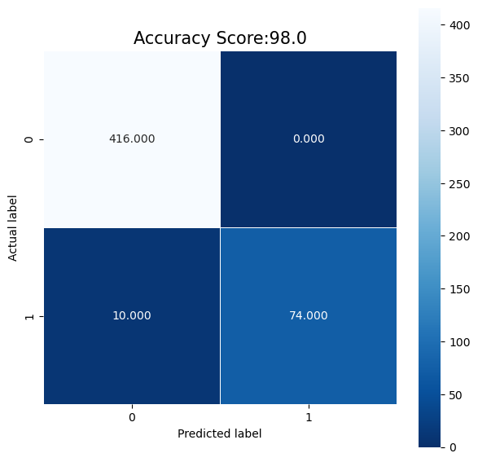

```python
predictions=n.predict(inputs,parameters);
accuracy=float((np.dot(targets,predictions.T)+np.dot(1-targets,1-predictions.T))/float(targets.size)*100);
print("Accuracy: " + str(accuracy));
print(" ")
cm=metrics.confusion_matrix(targets,predictions.T);
plt.figure(figsize=(7,7));
seaborn.heatmap(cm,annot=True,fmt=".3f",
            linewidths=.5,square=True,cmap='Blues_r');
plt.ylabel('Actual label');
plt.xlabel('Predicted label');
all_sample_title='Accuracy Score:{0}'.format(accuracy);
plt.title(all_sample_title,size=15);
print(" ")
recall=cm[0,0]/(cm[0,0]+cm[1,0]);
precision=cm[0,0]/(cm[0,0]+cm[0,1]);
accuracy=(cm[0,0]+cm[1,1])/(cm[0,0]+cm[0,1]+cm[1,0]+cm[1,1]);
F_measure=(2*recall*precision)/(recall+precision);
print("Recall: "+str(recall));
print("Precision: "+str(precision));
print("Accuracy: " + str(accuracy));
print("F-measure: "+str(F_measure));
```

The **NNLR** model achieved an accuracy $0.98$; out of the five-hundred observartion it correctly predicted 490 observations and incorrectly predicted teen observations; the result was slightly better than then the four-layered neural network generated by **Micrograd**.  
A common problem in mathematics is the interpolation of functions and data with interpolation methods; the most conventional method that have been utilizes range from legendre polynomials to hermite polynomials to spline interpolation. But during the 1990s mathematicians venture of the concept of utilizing neural networks as universal approximators [[22](https://mcneela.github.io/machine_learning/2017/03/21/Universal-Approximation-Theorem.html), [23](https://en.wikipedia.org/wiki/Universal_approximation_theorem)], some sampling of literature, *Constructive approximate interpolation by neural networks (2006)* by B. Llanas and F.J. Sainz [[24](https://mcneela.github.io/machine_learning/2017/03/21/Universal-Approximation-Theorem.html)], *A rapid supervised learning neural network for function interpolation and approximation (1996)* by C.L.P. Chen [[25](https://ieeexplore.ieee.org/abstract/document/536316/authors#authors)], and *Artificial neural networks as a tool for spatial interpolation* by Juan P. Rigol, Claire H. Jarvis and Neil Stuart [[26](https://www.tandfonline.com/doi/abs/10.1080/13658810110038951)].  
In case of the **NNLR** model, because it possesses a hardcoded code architecture for it to become an interpolating neural network; we would have to rewrite entire `Neural_Network` class function. In the case of the four-layered neural network generated by **Micrograd**, the only portion of the code was must change is the `loss` function; then it would become capable of interpolating a mathematics function, such as, $f(x)=x^{2}$. Consequentially we computated $f(x)=x^{2}$ and plotted the result in the following code block.

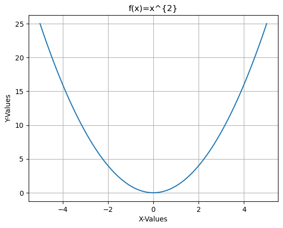

```python
X=np.array(np.linspace(-5,5,100));
Y=X**2;
plt.plot(X,Y)
plt.grid()
plt.title("f(x)=x^{2}");
plt.xlabel("X-Values");
plt.ylabel("Y-Values");
plt.show();
```

We changed the loss-function from cross entropy to mean-squared error, and replace accuracy with L2-norm error - which measures the absolute error magnitude. Note we did not re-initate the first four-layered neural network generated by **Micrograd** that was used to classify credit card applicant data; we just changed the `loss` function and began retraining it for the purpose of interpolation.

```python
# loss function
def loss(X,Y):
    Xb=X; y=Y;
    inputs=[[Value(xrow)] for xrow in Xb];

    # feed-forward the model to get scores (e.g. model's predictions)
    scores=list(map(model,inputs));

    # Mean Squared Error loss function
    losses=[(yi-scorei)**2 for yi, scorei in zip(y,scores)];
    total_loss=sum(losses)*(1.0/len(losses));

    # L2-Norm error formula
    diff=[yi-scorei.data for yi,scorei in zip(Y,scores)]
    L2_Norm=np.linalg.norm(diff);
    return total_loss,L2_Norm;

total_loss,L2Norm=loss(X,Y);
print(total_loss,L2Norm);
```

```
Value(data=139.4215327334246, grad=0) 118.07689559495736
```

```python
# optimization
for k in range(400):

    # forward
    total_loss,acc=loss(X,Y)

    # backward
    model.zero_grad()
    total_loss.backward()

    # update (sgd)
    learning_rate=0.05
    for p in model.parameters():
        p.data-=learning_rate*p.grad

    if k % 10 == 0:
        print(f"step: {k} loss: {total_loss.data}, L-2 Norm Error: {acc}")
```

```
step: 0 loss: 139.4215327334246, L-2 Norm Error: 118.07689559495736
step: 10 loss: 78.16474862877314, L-2 Norm Error: 88.41083000898314
step: 20 loss: 43.324235806214396, L-2 Norm Error: 65.82114842982791
step: 30 loss: 44.59537129071739, L-2 Norm Error: 66.77976586565526
step: 40 loss: 22.492288063520906, L-2 Norm Error: 47.4260351110241
step: 50 loss: 30.833958374622068, L-2 Norm Error: 55.52833364564623
step: 60 loss: 41.31396097544053, L-2 Norm Error: 64.27593715803802
step: 70 loss: 28.46529399998985, L-2 Norm Error: 53.352876211118975
step: 80 loss: 15.893041051893897, L-2 Norm Error: 39.8660771231556
step: 90 loss: 26.462783163757635, L-2 Norm Error: 51.441989817422154
step: 100 loss: 11.627007613841686, L-2 Norm Error: 34.09839822314486
step: 110 loss: 17.76392163121012, L-2 Norm Error: 42.14726756411396
step: 120 loss: 9.539573849915193, L-2 Norm Error: 30.886200559335865
step: 130 loss: 9.6357788860173, L-2 Norm Error: 31.04155100187053
step: 140 loss: 9.49632651397978, L-2 Norm Error: 30.8161102574283
step: 150 loss: 8.167447847093433, L-2 Norm Error: 28.578747080817653
step: 160 loss: 8.625066490609147, L-2 Norm Error: 29.36846351208919
step: 170 loss: 11.535296280603143, L-2 Norm Error: 33.963651571353665
step: 180 loss: 8.351769296251408, L-2 Norm Error: 28.899427842522087
step: 190 loss: 13.882750684216482, L-2 Norm Error: 37.25956344915555
step: 200 loss: 12.347476456394059, L-2 Norm Error: 35.13897616094422
step: 210 loss: 11.529495744077261, L-2 Norm Error: 33.955111167653776
step: 220 loss: 10.869368511512308, L-2 Norm Error: 32.968725349203766
step: 230 loss: 10.000308094697814, L-2 Norm Error: 31.62326373842178
step: 240 loss: 8.808907735912905, L-2 Norm Error: 29.679804136673315
step: 250 loss: 4.742214142568742, L-2 Norm Error: 21.776625410216205
step: 260 loss: 3.041336669102806, L-2 Norm Error: 17.439428514440504
step: 270 loss: 5.440204583339725, L-2 Norm Error: 23.324246147174243
step: 280 loss: 6.425427656035197, L-2 Norm Error: 25.348427280672066
step: 290 loss: 5.510583737063208, L-2 Norm Error: 23.474632557429324
step: 300 loss: 3.980667804923673, L-2 Norm Error: 19.951610974865343
step: 310 loss: 6.221518625017969, L-2 Norm Error: 24.942972206651653
step: 320 loss: 24.632610470027835, L-2 Norm Error: 49.631250709636404
step: 330 loss: 7.479885121462375, L-2 Norm Error: 27.34937864278159
step: 340 loss: 7.186961817331445, L-2 Norm Error: 26.80850950226708
step: 350 loss: 7.716462955872447, L-2 Norm Error: 27.77852219948435
step: 360 loss: 7.813611501225251, L-2 Norm Error: 27.952837961869367
step: 370 loss: 7.41636722015368, L-2 Norm Error: 27.233007950194704
step: 380 loss: 7.2698098319169, L-2 Norm Error: 26.962584875929277
step: 390 loss: 4.092530229015593, L-2 Norm Error: 20.230003037606274
```

Upon the completion of the training, we plotted the result in the following code block. The neural network approximation is the dashed line and the blue curve is the original function, $f(x)=x^{2}$. Noteably the neural network needed more iterations, so that it could learn the function better; but for the next demonstration we will utilize the pathological $f(x)$ that we chose earlier.

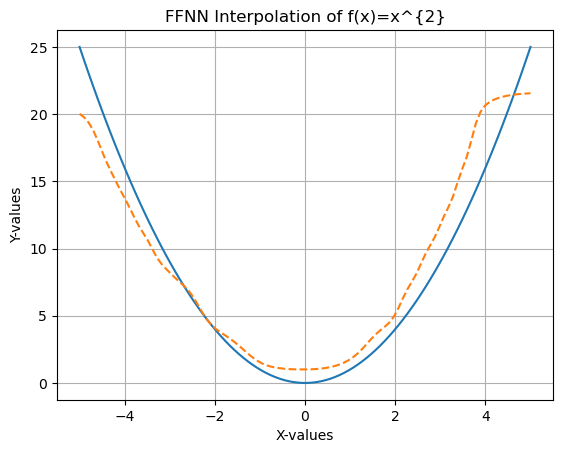

```python
inputs=[[Value(xrow)] for xrow in X];
scores=list(map(model,inputs));
interpolate=np.array([scorei.data for scorei in scores]);
plt.plot(X,Y);
plt.plot(X,interpolate,linestyle='dashed');
plt.title("FFNN Interpolation of f(x)=x^{2}");
plt.xlabel("X-values");
plt.ylabel("Y-values");
plt.grid();
plt.show();
```

For this final demonstration, we re-initiated the `model` as a 5-layered neural network with 1,376 parameters; so `model` can now be considered a deep learning model.

```python
# initialize a model
model=MLP(1,[25,25,25,1]) # 5-layer neural network
print(model);
print("number of parameters", len(model.parameters()));
```

```
MLP of [Layer of [tanh()Neuron(1), tanh()Neuron(1), tanh()Neuron(1), tanh()Neuron(1), tanh()Neuron(1), tanh()Neuron(1), tanh()Neuron(1), tanh()Neuron(1), tanh()Neuron(1), tanh()Neuron(1), tanh()Neuron(1), tanh()Neuron(1), tanh()Neuron(1), tanh()Neuron(1), tanh()Neuron(1), tanh()Neuron(1), tanh()Neur…
number of parameters 1376
```

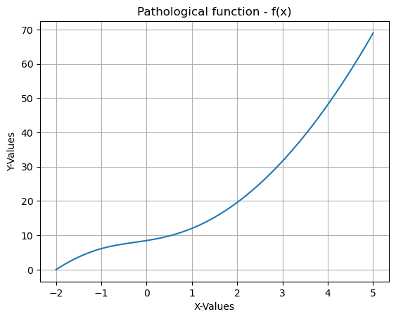

```python
X=np.array(np.linspace(-1.9999,5,100));
Y=(3*(X+2)*(X**2+4))/(2*(X**2+(2*X)+4))**(1/2);
plt.plot(X,Y);
plt.grid();
plt.title("Pathological function - f(x)");
plt.xlabel("X-Values");
plt.ylabel("Y-Values");
plt.show();
```

```python
# loss function
def loss(X,Y):
    Xb=X; y=Y;
    inputs=[[Value(xrow)] for xrow in Xb];

    # Forward propagation: feed-forward the model to get scores (e.g. model's predictions)
    scores=list(map(model,inputs));

    # Mean Squared Error loss function
    losses=[np.linalg.norm(yi-scorei) for yi,scorei in zip(y,scores)];
    total_loss=sum(losses)*(1.0/len(losses));

    # also get accuracy
    diff=[yi-scorei.data for yi,scorei in zip(Y,scores)]
    accuracy=np.linalg.norm(diff);
    return total_loss,accuracy;

total_loss,acc=loss(X,Y);
print(total_loss,acc);
```

```
Value(data=22.900666417417337, grad=0) 297.34248540518087
```

```python
# optimization
for k in range(700):

    # forward
    total_loss,acc=loss(X,Y)

    # backward
    model.zero_grad()
    total_loss.backward()

    # update (sgd)
    learning_rate=0.05
    for p in model.parameters():
        p.data-=learning_rate*p.grad

    if k%20==0:
        print(f"step: {k} loss: {total_loss.data}, L-2 Norm Error: {acc}")
```

```
step: 0 loss: 22.900666417417337, L-2 Norm Error: 297.34248540518087
step: 20 loss: 10.713301864289607, L-2 Norm Error: 177.81005398435326
step: 40 loss: 7.904822457362284, L-2 Norm Error: 140.4482604508394
step: 60 loss: 8.165532454626213, L-2 Norm Error: 122.33841323197503
step: 80 loss: 7.409924888426821, L-2 Norm Error: 107.5830137892493
step: 100 loss: 4.720773648369261, L-2 Norm Error: 83.43131649203451
step: 120 loss: 5.721442234354303, L-2 Norm Error: 87.29457362475159
step: 140 loss: 3.3389496965995593, L-2 Norm Error: 64.95170262943998
step: 160 loss: 3.498254577530628, L-2 Norm Error: 62.95429604639364
step: 180 loss: 3.222038527110634, L-2 Norm Error: 56.57379342161378
step: 200 loss: 6.071181454158955, L-2 Norm Error: 92.50838239696726
step: 220 loss: 4.855996456358606, L-2 Norm Error: 72.21099773302012
step: 240 loss: 3.153467045007156, L-2 Norm Error: 54.26993124343244
step: 260 loss: 3.685989276802195, L-2 Norm Error: 63.99115255654586
step: 280 loss: 3.164097814711429, L-2 Norm Error: 50.77197761197711
step: 300 loss: 3.6233662445546915, L-2 Norm Error: 54.027575560716265
step: 320 loss: 2.702363315476149, L-2 Norm Error: 47.81294339054739
step: 340 loss: 2.9965780941009825, L-2 Norm Error: 49.9059040751598
step: 360 loss: 2.284942439277919, L-2 Norm Error: 38.153305889649765
step: 380 loss: 4.29446895579619, L-2 Norm Error: 65.63824857985068
step: 400 loss: 3.1766914280670338, L-2 Norm Error: 49.13957760811045
step: 420 loss: 4.941813448568064, L-2 Norm Error: 66.98612298987379
step: 440 loss: 1.411797894232375, L-2 Norm Error: 27.46708428434756
step: 460 loss: 2.526866364473145, L-2 Norm Error: 43.63707083921693
step: 480 loss: 3.031169086706149, L-2 Norm Error: 44.8057193375222
step: 500 loss: 2.7534120363694017, L-2 Norm Error: 44.5096303692974
step: 520 loss: 3.7609625754740454, L-2 Norm Error: 55.88365041436123
step: 540 loss: 1.2106516004275085, L-2 Norm Error: 22.899810231703665
step: 560 loss: 1.2371067011723744, L-2 Norm Error: 20.826353505450165
step: 580 loss: 1.2833014049139682, L-2 Norm Error: 21.18201488955513
step: 600 loss: 1.7827189098209077, L-2 Norm Error: 26.051428410761346
step: 620 loss: 1.3944062727056408, L-2 Norm Error: 25.310097885271112
step: 640 loss: 2.6864440689819147, L-2 Norm Error: 43.69241830355399
step: 660 loss: 2.5254574997334878, L-2 Norm Error: 38.18347844730991
step: 680 loss: 0.9500378956811326, L-2 Norm Error: 17.676688519260868
```

Upon completion of the neural network's training, we plotted the results in the following code block; it results were far better then the first interpolation example - though the neural network still need more iteration to learn the function better.

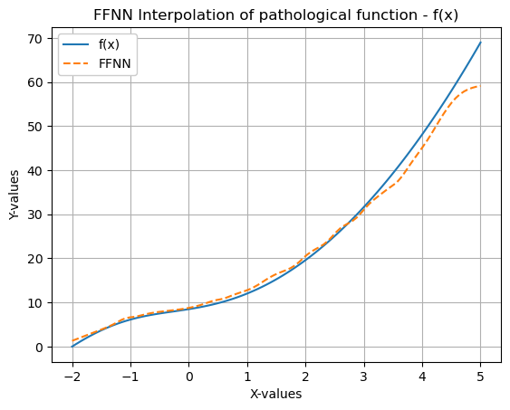

```python
inputs=[[Value(xrow)] for xrow in X];
scores=list(map(model,inputs));
interpolate=np.array([scorei.data for scorei in scores]);
plt.plot(X,Y,label='f(x)');
plt.plot(X,interpolate,linestyle='dashed',label='FFNN');
plt.title("FFNN Interpolation of pathological function - f(x)");
plt.xlabel("X-values");
plt.ylabel("Y-values");
plt.legend(framealpha=1,frameon=True);
plt.grid();
plt.show();
```

In conclusion **Micrograd** is a fantastic Python package for neural network development, it usage can be from proto-typing neural network concepts to low intensity real-world data applications. The significant issue that hold this package back is the lack of parallelization, though that was not part of Andrej Karpathy's original intent for this Python package. And anyhow, if one model require million by million dataset, PyTorch is the more appropriate for medium and high intensity application, as it possesses parallelization functionality. Nevertheless **Micrograd** is a great teaching tool for neural network development, and a fantastic tool for low-intensity neural network appliations, such as credit card applicant selection and univariate function approximation.  
This will conlude our inquiry on this topic; in the next project, we will cover the use of Pytorch and parallelization. We hope this project was useful for the reader, and we wish the reader a wonderful day.

### Citations:

- [0]: Rackauckas, Chris. Parallel Computing and Scientific Machine Learning (SciML): Methods and Applications, 08: Forward-Mode Automatic Differentiation (AD) via High Dimensional Algebra. Chris Rackauckas, 2023.  
  Url: https://book.sciml.ai/notes/08-Forward-Mode_Automatic_Differentiation_(AD)_via_High_Dimensional_Algebras/
- [1]: Rackauckas, Chris. Parallel Computing and Scientific Machine Learning (SciML): Methods and Applications, 10: Basic Parameter Estimation Reverse-Mode AD and Inverse Problems. Chris Rackauckas, 2023.  
  Url: https://book.sciml.ai/notes/10-Basic_Parameter_Estimation-Reverse-Mode_AD-and_Inverse_Problems/
- [2]: Elliot, Conal. The Simple Essence of Automatic Differentiation - Extended version. Target Corporation, 2018.  
  Url: https://arxiv.org/pdf/1804.00746.pdf
- [3]: Baydin, Atılım Gunes. Pearlmutter, Barak A. Radul, Alexey Andreyevich. Siskind, Jeffrey Mark. Automatic Differentiation in Machine Learning: a Survey. Journal of Machine Learning Research, 2018.  
  Url: https://www.jmlr.org/papers/volume18/17-468/17-468.pdf
- [4]: Username: TMN. Answer to: CPU Architecture and floating-point math. StackExchange forum, November 21, 2011.  
  Url: https://softwareengineering.stackexchange.com/questions/120886/cpu-architecture-and-floating-point-math
- [5]: Murray, Richard. Floating point instructions. https://heyrick.eu/index.html, 2004.  
  Url: https://heyrick.eu/assembler/fpops.html
- [6]: IEEE 754 (IEEE Standard for Floating-Point Arithmetic). Wikipedia, January 23, 2023.  
  Url: https://en.wikipedia.org/wiki/IEEE_754
- [7]: Paszke, Adam. Gross, Sam. Chintala, Soumith. Chanan, Gregory. Yang, Edward. DeVito, Zachary. Lin, Zeming. Desmaison, Alban. Antiga, Luca. Lerer, Adam. Automatic differentiation in PyTorch. OpenReview, 2017.  
  Url: https://openreview.net/pdf?id=BJJsrmfCZ
- [8]: Preferred Networks, Inc. Overview of PyTorch Autograd Engine. PyTorch, June 08, 2021.  
  Url: https://pytorch.org/blog/overview-of-pytorch-autograd-engine/
- [9]: Automatic Differentiation with `TORCH.AUTOGRAD`. PyTorch, 2022.  
  Url: https://pytorch.org/tutorials/beginner/basics/autogradqs_tutorial.html
- [10]: Karpathy, Andrej. Github: Karpathy/micrograd. Github, April 18, 2020.  
  Url: https://github.com/karpathy/micrograd
- [11]: Karpathy, Andrej. Github: Karpathy/micrograd/engine.py. Github, April 18, 2020.  
  Url: https://github.com/karpathy/micrograd/blob/master/micrograd/engine.py
- [12]: Elementary function. Wikipedia, January 1, 2023.  
  Url: https://en.wikipedia.org/wiki/Elementary_function
- [13]: Activation function. Wikipedia, January 29, 2023.  
  Url: https://en.wikipedia.org/wiki/Activation_function
- [14]: M. H. Protter. C. B. Morrey. A First Course in Real Analysis. Springer New York, NY, December 6, 2012.  
  Url: https://doi.org/10.1007/978-1-4615-9990-6
- [15]: Double-precision floating-point format. Wikipedia, December 22, 2022.  
  Url: https://en.wikipedia.org/wiki/Double-precision_floating-point_format#IEEE_754_double-precision_binary_floating-point_format:_binary64
- [16]: Finite difference method. Wikipedia, February 11, 2023.  
  Url: https://en.wikipedia.org/wiki/Finite_difference_method
- [17]: Karpathy, Andrej. The spelled-out intro to neural networks and backpropagation: building micrograd. Wikipedia, February 11, 2023.  
  Url: https://www.youtube.com/watch?v=VMj-3S1tku0&ab_channel=AndrejKarpathy
- [18]: van Hoeij, Mark. Closed Form Solutions. Florida State University, ISSAC, 2017.  
  Url: https://www.math.fsu.edu/~hoeij/issac2017.pdf
- [19]: Closed-Form Solution. Wolfram MathWorld, 2023.  
  Url: https://mathworld.wolfram.com/Closed-FormSolution.html
- [20]: Daemi, Barry. Logistic Regression via FFNN (Feedforward Neural Network). Southern Methodist University, January 10, 2023.  
  Url: https://barryhabsburg.github.io/Logistic_Regression_via_FFNN_version2.html
- [21]: Spipy.stats.bernoulli. https://docs.scipy.org.  
  Url: https://docs.scipy.org/doc/scipy/reference/generated/scipy.stats.bernoulli.html
- [22]: Mcneela, Daniel. The Universal Approximation Theorem For Neural Networks. Github.  
  Url: https://mcneela.github.io/machine_learning/2017/03/21/Universal-Approximation-Theorem.html
- [23]: Universal approximation theorem. Wikipedia, February 17, 2023.  
  Url: https://mcneela.github.io/machine_learning/2017/03/21/Universal-Approximation-Theorem.html
- [23]: Universal approximation theorem. Wikipedia, February 17, 2023.  
  Url: https://mcneela.github.io/machine_learning/2017/03/21/Universal-Approximation-Theorem.html
- [24]: Llanas, B. Sainz, F.J. Constructive approximate interpolation by neural networks. ScienceDirect, April 15, 2006.  
  Url: https://doi.org/10.1016/j.cam.2005.04.019
- [25]: Chen, C.L.P. A rapid supervised learning neural network for function interpolation and approximation. IEEE, September 1996.  
  Url: https://doi.org/10.1109/72.536316
- [25]: Rigol, Juan P. Jarvis, Chris H. Stuart, Neil. Artificial neural networks as a tool for spatial interpolation. Taylor & Francis Online, September 2001.  
  Url: https://doi.org/10.1080/13658810110038951